# Predicting Hotel Booking Cancellations

Author

Dylan Ma

# Introduction

This project uses the Hotel Booking Demand dataset to predict whether a hotel booking will be canceled. The main research question is:

> Can booking time characteristics and customer history predict hotel booking cancellations?

The analysis combines exploratory data analysis, feature engineering, cross-validation, and several classification models. Model performance is evaluated using ROC AUC together with accuracy, sensitivity, specificity, precision, and the F1 score.

# Setup

```python
# Import libraries for data analysis and visualization
import pandas as pd
import numpy as np
import matplotlib.pyplot as plt
from matplotlib.ticker import PercentFormatter


# Import utilities for file paths, model storage, and module reloading
from pathlib import Path
from joblib import dump, load
import importlib

# Table display setting during interactive analysis
pd.set_option("display.max_columns", None)
pd.set_option("display.max_rows", 100)

# Set the random state for data splitting and model fitting
RANDOM_STATE = 20240504


# Save fitted models
MODEL_DIR = Path("saved_models")
MODEL_DIR.mkdir(exist_ok=True)



RETRAIN_MODELS = False
```

# Data

## Data Overview

The dataset was obtained from the [Hotel Booking Demand](https://www.kaggle.com/datasets/jessemostipak/hotel-booking-demand) dataset on Kaggle. It was originally collected and published in an article by António, de Almeida, and Nunes (2019). Each observation represents a booking scheduled to arrive between July 2015 and August 2017, including both completed and canceled bookings

```python
# Load the original hotel booking data
data_path = Path("data/hotel_bookings.csv")
# Load the CSV file
hotel = pd.read_csv(data_path)

# Store dataset dimensions and data types
data_overview = pd.DataFrame({
    "Observations": [hotel.shape[0]],
    "Variables": [hotel.shape[1]],
    "Numeric columns": [hotel.select_dtypes(include="number").shape[1]],
    "Non-numeric columns": [hotel.select_dtypes(exclude="number").shape[1]],
    "Response": ["is_canceled"],
})

# Display a compact overview without the index
display(
    data_overview.style
    .format({
        "Observations": "{:,}",
        "Variables": "{:,}",
        "Numeric columns": "{:,}",
        "Non-numeric columns": "{:,}",
    })
    .hide(axis="index")
)
```

| Observations | Variables | Numeric columns | Non-numeric columns | Response |
| --- | --- | --- | --- | --- |
| 119,390 | 32 | 20 | 12 | is_canceled |

The original dataset contains 119,390 observations and 32 variables, including 20 numeric and 12 non-numeric candidates. The binary response variable, is_canceled, indicates whether a booking was canceled. The other variables provide information about booking characteristics, customer history, stay details, and reservation channels.

## Data Cleaning

### Duplicate Observations

```python
# Count exact duplicate observations
n_original = len(hotel)
n_duplicates = hotel.duplicated().sum()
duplicate_pct = n_duplicates / n_original

# Remove duplicates
hotel_clean = hotel.drop_duplicates().copy()

# Verify that no exact duplicates remain
assert hotel_clean.duplicated().sum() == 0

# Summarize the duplicate-removal results
duplicate_summary = pd.DataFrame({
    "Original observations": [n_original],
    "Exact duplicates removed": [n_duplicates],
    "Percentage removed": [duplicate_pct],
    "Remaining observations": [len(hotel_clean)],
})

display(
    duplicate_summary.style
    .format({
        "Original observations": "{:,}",
        "Exact duplicates removed": "{:,}",
        "Percentage removed": "{:.2%}",
        "Remaining observations": "{:,}",
    })
    .hide(axis="index")
)
```

| Original observations | Exact duplicates removed | Percentage removed | Remaining observations |
| --- | --- | --- | --- |
| 119,390 | 31,994 | 26.80% | 87,396 |

A total of 31,994 (26.8% of the original dataset) exact duplicate observations were identified. These duplicates were removed before splitting into training and test sets to prevent identical observations from appearing in both sets, which could potentially provide an overly optimistic estimate of model performance. After removing the duplicates, 87,396 unique observations remained for analysis and modeling.

### Missing Data

```python
# Audit the data types, missingness, and unique values
audit = pd.DataFrame({
    "Data type": hotel_clean.dtypes.astype(str),
    "Missing values": hotel_clean.isna().sum(),
    "Missing percentage": hotel_clean.isna().mean(),
    "Unique values": hotel_clean.nunique(),
})

# Keep only variables containing missing values
missing_summary = (
    audit.loc[audit["Missing values"] > 0]
    .sort_values("Missing percentage", ascending=False)
    .rename_axis("Variable")
    .reset_index()
)

display(
    missing_summary.style
    .format({
        "Missing values": "{:,}",
        "Missing percentage": "{:.2%}",
        "Unique values": "{:,}",
    })
    .hide(axis="index")
)
```

| Variable | Data type | Missing values | Missing percentage | Unique values |
| --- | --- | --- | --- | --- |
| company | float64 | 82,137 | 93.98% | 352 |
| agent | float64 | 12,193 | 13.95% | 333 |
| country | str | 452 | 0.52% | 177 |
| children | float64 | 4 | 0.00% | 5 |

After duplicate removal, missing values are found in four variables. `company` had 82,137 such values (93.98%), followed by `agent` with 12,193 (13.95%), `country` with 452 (0.52%), and `children` with only four. According to the dataset documentation, missing values in `company` and `agent` indicate that these fields were not applicable rather than unknown. Because `company` was highly sparse and contained many distinct identifiers, it will be replaced with a binary indicator showing whether a company is associated with each booking. `agent` will be retained as a categorical variable, with ‘NA’ entries labeled as `No Agent`, and infrequent agent categories will later be grouped before one-hot encoding. Missing `country` values will be labeled as `Unknown Country` as a separate category. The four missing children values were retained at this stage and will be imputed within the preprocessing pipeline using a value learned from the training data.

```python
# Replace the sparse company ID with an availability indicator
hotel_clean["has_company"] = hotel_clean["company"].notna().astype(int)
hotel_clean = hotel_clean.drop(columns=["company"])


# agent: encode missing values as "No Agent" and treat IDs as categories ( unique IDs will be grouped later)
hotel_clean["agent"] = (
    hotel_clean["agent"]
    .astype("Int64")
    .astype("string")
    .fillna("No Agent")
)


# country: encode missing values as "Unknown Country" (keeps unknown countries separate from rare observed countries)
hotel_clean["country"] = (
    hotel_clean["country"]
    .astype("string")
    .fillna("Unknown Country")
)


# Verify the deterministic missing-value treatments
assert "company" not in hotel_clean.columns
assert hotel_clean["has_company"].isin([0, 1]).all()
assert hotel_clean[["agent", "country"]].isna().sum().sum() == 0
```

### Potential Data Leakage

```python
# Examine whether reservation status reveals the response
leakage_summary = (
    hotel_clean
    .groupby("reservation_status", as_index=False)
    .agg(
        Observations=("is_canceled", "size"),
        cancellation_rate=("is_canceled", "mean"),
    )
    .rename(columns={
        "reservation_status": "Reservation status",
        "cancellation_rate": "Cancellation rate",
    })
)

display(
    leakage_summary.style
    .format({
        "Observations": "{:,}",
        "Cancellation rate": "{:.2%}",
    })
    .hide(axis="index")
)

# Remove variables that contain post-outcome information
hotel_clean = hotel_clean.drop(columns=[
    "reservation_status",
    "reservation_status_date",
])
```

| Reservation status | Observations | Cancellation rate |
| --- | --- | --- |
| Canceled | 23,011 | 100.00% |
| Check-Out | 63,371 | 0.00% |
| No-Show | 1,014 | 100.00% |

`reservation_status` was identified as a source of data leakage because it directly reflects the final outcome of a booking. All observations with a status of Canceled or No-Show had `is_canceled` = 1, while all Check-Out observations had `is_canceled = 0`. `reservation_status_date` was also excluded because it records when the final status was assigned and is therefore only known after the booking outcome. Both variables were removed before modeling.

### Suspicious or Invalid Values

```python
total_nights = (
    hotel_clean["stays_in_weekend_nights"]
    + hotel_clean["stays_in_week_nights"]
)

# Inspect the ranges of variables with potentially questionable values
range_summary = (
    hotel_clean
    .assign(total_nights=total_nights)
    [["adults", "children", "babies", "total_nights", "adr"]]
    .describe(percentiles=[0.50, 0.999])
    .T
    [["min", "50%", "99.9%", "max"]]
    .rename_axis("Variable")
    .reset_index()
)

display(
    range_summary.style
    .format({
        "min": "{:,.2f}",
        "50%": "{:,.2f}",
        "99.9%": "{:,.2f}",
        "max": "{:,.2f}",
    })
    .hide(axis="index")
)



# Summarize potentially suspicious or unusual observations
suspicious_summary = pd.DataFrame({
    "Check": [
        "Zero adults",
        "Zero total guests",
        "Zero total nights",
        "Negative ADR",
        "Adults above 20",
        "Children above 3",
        "Babies above 2"
    ],
    "Count": [
        (hotel_clean["adults"] == 0).sum(),

        (
            (hotel_clean["adults"] == 0) &
            (hotel_clean["children"] == 0) &
            (hotel_clean["babies"] == 0)
        ).sum(),

        (
            hotel_clean["stays_in_weekend_nights"] +
            hotel_clean["stays_in_week_nights"] == 0
        ).sum(),

        (hotel_clean["adr"] < 0).sum(),
        (hotel_clean["adults"] > 20).sum(),
        (hotel_clean["children"] > 3).sum(),
        (hotel_clean["babies"] > 2).sum()
    ]
})

display(suspicious_summary)
```

| Variable | min | 50% | 99.9% | max |
| --- | --- | --- | --- | --- |
| adults | 0.00 | 2.00 | 3.00 | 55.00 |
| children | 0.00 | 0.00 | 2.00 | 10.00 |
| babies | 0.00 | 0.00 | 1.00 | 10.00 |
| total_nights | 0.00 | 3.00 | 27.00 | 69.00 |
| adr | -6.38 | 98.10 | 335.00 | 5,400.00 |

|  | Check | Count |
| --- | --- | --- |
| 0 | Zero adults | 385 |
| 1 | Zero total guests | 166 |
| 2 | Zero total nights | 651 |
| 3 | Negative ADR | 1 |
| 4 | Adults above 20 | 10 |
| 5 | Children above 3 | 1 |
| 6 | Babies above 2 | 2 |

Initial screening identified several suspicious observations, including bookings with no recorded guests, bookings with zero nights, extreme values of children, babies, ADR and adults. Because extreme values are not necessarily data errors, these observations were examined in greater detail before making any cleaning decisions.

#### Zero Adults and Zero Guests

```python
# Identify bookings with no recorded adults
zero_adults = hotel_clean[hotel_clean["adults"] == 0]

# Separate confirmed zero-guest bookings
zero_guests = zero_adults[(zero_adults["children"] == 0)& (zero_adults["babies"] == 0)]

# Identify zero-adult bookings with children or babies
zero_adults_with_dependents = zero_adults[(zero_adults["children"] > 0)| (zero_adults["babies"] > 0)]

# Summarize the investigation
zero_guest_summary = pd.DataFrame({
    "Check": [
        "Zero adults",
        "Zero adults with children or babies",
        "Confirmed zero guests",
        "Zero guests also having zero total nights",
    ],
    "Count": [
        len(zero_adults),
        len(zero_adults_with_dependents),
        len(zero_guests),
        len(zero_guests[
            (zero_guests["stays_in_weekend_nights"] +
             zero_guests["stays_in_week_nights"]) == 0
        ])
    ],
})

display(
    zero_guest_summary.style
    .format({"Count": "{:,}"})
    .hide(axis="index")
)

# Remove bookings with no recorded guests
hotel_clean = hotel_clean.drop(index=zero_guests.index).copy()
```

| Check | Count |
| --- | --- |
| Zero adults | 385 |
| Zero adults with children or babies | 219 |
| Confirmed zero guests | 166 |
| Zero guests also having zero total nights | 60 |

There were 385 bookings with zero recorded adults. Further examination shows that 219 of these bookings included at least one child or baby and were therefore retained. The remaining 166 observations had zero recorded guest were treated as invalid bookings and removed.

#### Zero Total Nights

```python
# Restore reservation status for diagnostic analysis only
booking_details = hotel_clean.copy()
booking_details["reservation_status"] = hotel.loc[booking_details.index, "reservation_status"]

# Identify bookings with zero recorded nights
total_nights = (
    hotel_clean["stays_in_weekend_nights"]
    + hotel_clean["stays_in_week_nights"]
)

zero_nights = hotel_clean.loc[total_nights == 0].copy()

zero_night_details = booking_details.loc[zero_nights.index]

profile_vars = [
    "reservation_status",
    "market_segment",
    "customer_type",
    "distribution_channel",
]

tables = []

# Summarize each variable using the same comparison sample
for var in profile_vars:
    summary = pd.DataFrame({
        "Zero-night bookings": zero_night_details[var].value_counts(
            normalize=True
        ),
        "All bookings": booking_details[var].value_counts(
            normalize=True
        ),
    }).fillna(0)

    summary = summary[summary["Zero-night bookings"] >= 0.05]
    summary = summary.sort_values("Zero-night bookings", ascending=False)
    summary = summary.rename_axis("Category").reset_index()
    summary.insert(0, "Variable", var.replace("_", " ").title())

    tables.append(summary)

# Combine the summaries into one report table
profile = pd.concat(tables, ignore_index=True)

display(
    profile.style
    .format({
        "Zero-night bookings": "{:.1%}",
        "All bookings": "{:.1%}",
    })
    .hide(axis="index")
)
```

| Variable | Category | Zero-night bookings | All bookings |
| --- | --- | --- | --- |
| Reservation Status | Check-Out | 96.1% | 72.5% |
| Market Segment | Online TA | 45.3% | 59.1% |
| Market Segment | Direct | 21.7% | 13.5% |
| Market Segment | Offline TA/TO | 17.9% | 15.9% |
| Market Segment | Corporate | 7.6% | 4.8% |
| Market Segment | Groups | 5.1% | 5.6% |
| Customer Type | Transient | 83.9% | 82.4% |
| Customer Type | Transient-Party | 12.5% | 13.4% |
| Distribution Channel | TA/TO | 63.8% | 79.1% |
| Distribution Channel | Direct | 25.4% | 14.9% |
| Distribution Channel | Corporate | 10.3% | 5.8% |

After 60 was removed from the zero guest cleaning step, there were 591 bookings with zero recorded nights, and all of them had an ADR of zero. To investigate whether these observations represented a specific type of booking, we compared their reservation status, market segment, customer type, and distribution channel. About 96.1% were recorded as Check-Out, suggesting that most represented actual completed bookings rather than invalid records. However, they were not concentrated in any single segment, which is inconsistent with these being a distinct booking type. Online TA accounted for 45.3% of the bookings, followed by Direct (21.7%) and Offline TA/TO (17.9%), while only 5.1% were Groups. In addition, 83.9% were Transient customers. Therefore, we retain these bookings but treat their zero ADR and length-of-stay values as potentially missing or miscoded. We create adjusted variables `adr_adj` and `total_nights_adj`, setting both to missing for bookings with zero nights and zero ADR while leaving the original columns unchanged. The adjusted variables will be used for modeling, with missing values imputed within the preprocessing pipeline using medians learned from the training data.

```python
questionable_stay = (total_nights == 0) & (hotel_clean["adr"] == 0)

hotel_clean["adr_adj"] = hotel_clean["adr"].where(
    ~questionable_stay, np.nan
)

hotel_clean["total_nights_adj"] = total_nights.where(
    ~questionable_stay, np.nan
)
```

#### Extreme ADR Values

```python
# Identify bookings with a negative ADR
negative_adr = hotel_clean[
    hotel_clean["adr"] < 0
]

print(f"Bookings with negative ADR: {len(negative_adr):,}")

display(
    negative_adr[
        [
            "hotel",
            "is_canceled",
            "adults",
            "children",
            "babies",
            "stays_in_weekend_nights",
            "stays_in_week_nights",
            "adr",
            "market_segment",
            "customer_type",
            "deposit_type"
        ]
    ]
)

# Treat the negative ADR as missing in the adjusted variable
hotel_clean.loc[negative_adr.index, "adr_adj"] = np.nan
```

```
Bookings with negative ADR: 1
```

|  | hotel | is_canceled | adults | children | babies | stays_in_weekend_nights | stays_in_week_nights | adr | market_segment | customer_type | deposit_type |
| --- | --- | --- | --- | --- | --- | --- | --- | --- | --- | --- | --- |
| 14969 | Resort Hotel | 0 | 2 | 0.0 | 0 | 4 | 6 | -6.38 | Groups | Transient-Party | No Deposit |

One booking had a negative ADR of -6.38. Because the remaining booking information appeared valid, the observation was retained. The negative rate was treated as invalid for price-related analysis and set to missing in adr_adj for later imputation.

```python
# Compare the largest ADR values with nearby high values
display(
    hotel_clean.nlargest(5, "adr_adj")[
        [
            "hotel",
            "adr_adj",
            "stays_in_weekend_nights",
            "stays_in_week_nights",
            "market_segment",
            "customer_type",
        ]
    ].style.format({"adr_adj": "{:,.2f}"}).hide(axis="index")
)

# Treat the outlier as missing in the adjusted variable
hotel_clean.loc[hotel_clean["adr_adj"] > 1000, "adr_adj"] = np.nan
```

| hotel | adr_adj | stays_in_weekend_nights | stays_in_week_nights | market_segment | customer_type |
| --- | --- | --- | --- | --- | --- |
| City Hotel | 5,400.00 | 0 | 1 | Offline TA/TO | Transient |
| City Hotel | 510.00 | 0 | 1 | Offline TA/TO | Transient |
| Resort Hotel | 508.00 | 0 | 1 | Corporate | Transient |
| City Hotel | 451.50 | 1 | 1 | Direct | Transient-Party |
| Resort Hotel | 450.00 | 4 | 10 | Online TA | Transient |

ADR had a median of 98.10 and a 99.9th percentile of 335. Most high values remained below 510, but one booking recorded an ADR of 5,400, making it a clear outlier from the rest of the distribution. The booking was retained, while its ADR was set to missing in adr_adj for later imputation.

#### Large Adult Counts

```python
# Show bookings with the largest numbers of adults
hotel_clean.nlargest(10, "adults")[
    ["hotel", "adults", "children", "babies",
     "market_segment", "customer_type", "adr", "is_canceled"]
]
```

|  | hotel | adults | children | babies | market_segment | customer_type | adr | is_canceled |
| --- | --- | --- | --- | --- | --- | --- | --- | --- |
| 2173 | Resort Hotel | 55 | 0.0 | 0 | Direct | Group | 0.0 | 1 |
| 1643 | Resort Hotel | 50 | 0.0 | 0 | Direct | Group | 0.0 | 1 |
| 1539 | Resort Hotel | 40 | 0.0 | 0 | Direct | Group | 0.0 | 1 |
| 1917 | Resort Hotel | 27 | 0.0 | 0 | Direct | Group | 0.0 | 1 |
| 1962 | Resort Hotel | 27 | 0.0 | 0 | Direct | Group | 0.0 | 1 |
| 1587 | Resort Hotel | 26 | 0.0 | 0 | Offline TA/TO | Group | 0.0 | 1 |
| 1752 | Resort Hotel | 26 | 0.0 | 0 | Offline TA/TO | Group | 0.0 | 1 |
| 1884 | Resort Hotel | 26 | 0.0 | 0 | Offline TA/TO | Group | 0.0 | 1 |
| 2003 | Resort Hotel | 26 | 0.0 | 0 | Offline TA/TO | Group | 0.0 | 1 |
| 2164 | Resort Hotel | 26 | 0.0 | 0 | Offline TA/TO | Group | 0.0 | 1 |

Extremely large values of adults were primarily associated with bookings classified as Group, suggesting that these observations represented legitimate group reservations, therefore they will be retained.

#### Extreme Values in Number of Children

```python
# Examine the distribution of the number of children
display(
    hotel_clean["children"]
    .value_counts(dropna=False)
    .sort_index(na_position="last")
    .to_frame("count")
)

# Examine bookings with unusually large numbers of children
display(
    hotel_clean.loc[
        hotel_clean["children"] > 3,
        [
            "hotel",
            "adults",
            "children",
            "babies",
            "market_segment",
            "customer_type",
            "adr",
            "is_canceled"
        ]
    ]
)

extreme_children = hotel_clean[
    hotel_clean["children"] > 3
]

# Remove the isolated outlier in number of children
hotel_clean = hotel_clean.drop(index=extreme_children.index).copy()
```

| children | count |
| --- | --- |
| 0.0 | 78862 |
| 1.0 | 4695 |
| 2.0 | 3593 |
| 3.0 | 75 |
| 10.0 | 1 |
| NaN | 4 |

|  | hotel | adults | children | babies | market_segment | customer_type | adr | is_canceled |
| --- | --- | --- | --- | --- | --- | --- | --- | --- |
| 328 | Resort Hotel | 2 | 10.0 | 0 | Offline TA/TO | Contract | 133.16 | 1 |

The distribution of `children` was concentrated between zero and three. Only one booking recorded ten children, with no observations between four and nine. Because it included only two adults and was not classified under the Group market segment, it was treated as a likely data-entry error and removed.

#### Extreme Values in Number of Babies

```python
# Examine the distribution of the number of babies
display(
    hotel_clean["babies"]
    .value_counts()
    .sort_index()
    .to_frame("count")
)


# Examine bookings with unusually large numbers of babies
extreme_babies = hotel_clean[
    hotel_clean["babies"] > 2
]

print(f"Bookings with more than two babies: {len(extreme_babies):,}")

display(
    extreme_babies[
        [
            "hotel",
            "adults",
            "children",
            "babies",
            "market_segment",
            "customer_type",
            "adr",
            "is_canceled"
        ]
    ]
)
```

| babies | count |
| --- | --- |
| 0 | 86315 |
| 1 | 897 |
| 2 | 15 |
| 9 | 1 |
| 10 | 1 |

```
Bookings with more than two babies: 2
```

|  | hotel | adults | children | babies | market_segment | customer_type | adr | is_canceled |
| --- | --- | --- | --- | --- | --- | --- | --- | --- |
| 46619 | City Hotel | 2 | 0.0 | 10 | Online TA | Transient | 84.45 | 0 |
| 78656 | City Hotel | 1 | 0.0 | 9 | Corporate | Transient-Party | 95.00 | 0 |

The distribution of `babies` was concentrated between zero and two. Only two bookings recorded an unusually high number of babies (nine and ten), with no observations between three and eight. Both of the outlier groups involved only one or two adults and were not classified under the Group market segment. These isolated values were considered likely data-entry errors, so the two observations were removed.

```python
# Remove bookings with implausibly large numbers of babies
hotel_clean = hotel_clean.drop(index=extreme_babies.index).copy()
```

# Exploratory Data Analysis

## Train-Test Split

```python
from sklearn.model_selection import train_test_split

X = hotel_clean.drop(columns=["is_canceled"])
y = hotel_clean["is_canceled"]

X_train, X_test, y_train, y_test = train_test_split(
    X, y,
    test_size=0.2,
    stratify=y,
    random_state=RANDOM_STATE
)

train_df = X_train.copy()
train_df["is_canceled"] = y_train

print(f"Training set: {len(train_df):,} observations")
print(f"Test set: {len(X_test):,} observations")
```

```
Training set: 69,781 observations
Test set: 17,446 observations
```

## Response Variable

| is_canceled | count | proportion |
| --- | --- | --- |
| 0 | 50575 | 0.724767 |
| 1 | 19206 | 0.275233 |

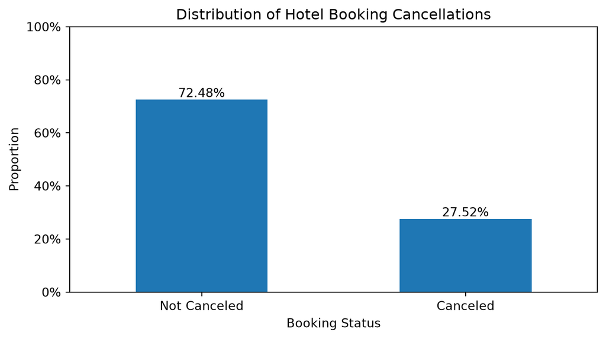

```python
# Calculate cancellation proportions for plotting

target_summary = (
    train_df["is_canceled"]
    .value_counts()
    .sort_index()
    .to_frame("count")
)

target_summary["proportion"] = (
    target_summary["count"] / len(train_df)
)

display(target_summary)


# Plot the distribution of the response variable
ax = target_summary["proportion"].plot(
    kind="bar",
    figsize=(7, 4),
    xlabel="Booking Status",
    ylabel="Proportion",
    title="Distribution of Hotel Booking Cancellations",
    rot=0
)

ax.set_xticks([0, 1], labels=["Not Canceled", "Canceled"])
ax.yaxis.set_major_formatter(PercentFormatter(1))
ax.set_ylim(0, 1)

for i, proportion in enumerate(target_summary["proportion"]):
    ax.text(
        i,
        proportion + 0.01,
        f"{proportion:.2%}",
        ha="center"
    )

plt.tight_layout()
plt.show()
```

The response variable, `is_canceled`, indicates whether a hotel booking was canceled. About 27.52% of the bookings in the training set were canceled, while 72.48% were not canceled. This indicates a moderate class imbalance, with canceled bookings representing the minority class.

## Bivariate Analysis

### Lead Time

| lead_time | bookings | cancellation_rate |
| --- | --- | --- |
| 0–7 | 14565 | 0.084174 |
| 8–30 | 13044 | 0.256056 |
| 31–90 | 18162 | 0.319238 |
| 91–180 | 14614 | 0.349802 |
| 181–365 | 8932 | 0.396104 |
| 366+ | 464 | 0.413793 |

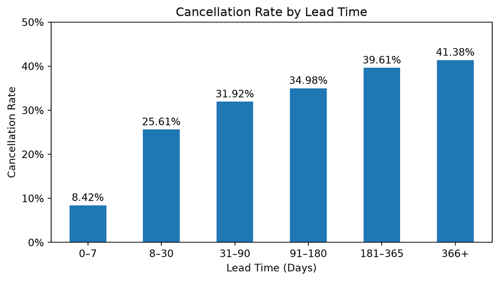

```python
# Group lead time and calculate cancellation rates
lead_time_group = pd.cut(
    train_df["lead_time"],
    bins=[-1, 7, 30, 90, 180, 365, np.inf],
    labels=["0–7", "8–30", "31–90", "91–180", "181–365", "366+"]
)

lead_time_summary = (
    train_df.groupby(lead_time_group, observed=False)["is_canceled"]
    .agg(
        bookings="size",
        cancellation_rate="mean"
    )
)

display(lead_time_summary)



ax = lead_time_summary["cancellation_rate"].plot(
    kind="bar",
    figsize=(7, 4),
    xlabel="Lead Time (Days)",
    ylabel="Cancellation Rate",
    title="Cancellation Rate by Lead Time",
    rot=0
)

ax.yaxis.set_major_formatter(PercentFormatter(1))
ax.set_ylim(0, 0.5)


for i, rate in enumerate(lead_time_summary["cancellation_rate"]):
    ax.text(
        i,
        rate + 0.01,
        f"{rate:.2%}",
        ha="center"
    )



plt.tight_layout()
plt.show()
```

Cancellation rates increased steadily with lead time.This clear positive relationship suggests that `lead_time` may be an important predictor of cancellation. However, the final interval contains only 464 bookings, so its estimated cancellation rate may be less stable.

### Deposit Type

| deposit_type | bookings | cancellation_rate |
| --- | --- | --- |
| Refundable | 86 | 0.244186 |
| No Deposit | 68850 | 0.267044 |
| Non Refund | 845 | 0.945562 |

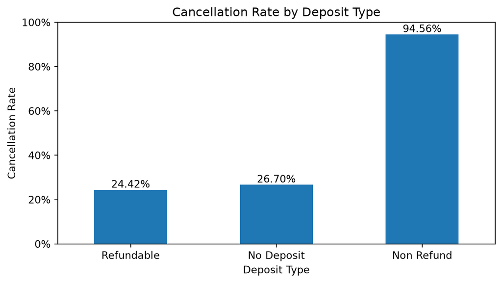

```python
# Summarize cancellations by deposit type
deposit_summary = (
    train_df.groupby("deposit_type")["is_canceled"]
    .agg(
        bookings="size",
        cancellation_rate="mean"
    )
    .sort_values("cancellation_rate")
)

display(deposit_summary)

# Plot cancellation rate by deposit type
ax = deposit_summary["cancellation_rate"].plot(
    kind="bar",
    figsize=(7, 4),
    xlabel="Deposit Type",
    ylabel="Cancellation Rate",
    title="Cancellation Rate by Deposit Type",
    rot=0
)


ax.yaxis.set_major_formatter(PercentFormatter(1))
ax.set_ylim(0, 1)

for i, rate in enumerate(deposit_summary["cancellation_rate"]):
    ax.text(
        i,
        rate + 0.01,
        f"{rate:.2%}",
        ha="center"
    )


plt.tight_layout()
plt.show()
```

Deposit type also showed a strong relationship with cancellation. Bookings with a non-refundable deposit had a cancellation rate of 94.56%, compared with 26.70% for bookings with no deposit and 24.42% for refundable deposits. This large difference suggests that `deposit_type` may be an important predictor of cancellation.

### Previous Cancellations

| previous_cancellations | bookings | cancellation_rate |
| --- | --- | --- |
| 0 | 68422 | 0.267195 |
| 1 | 1127 | 0.764862 |
| 2+ | 232 | 0.267241 |

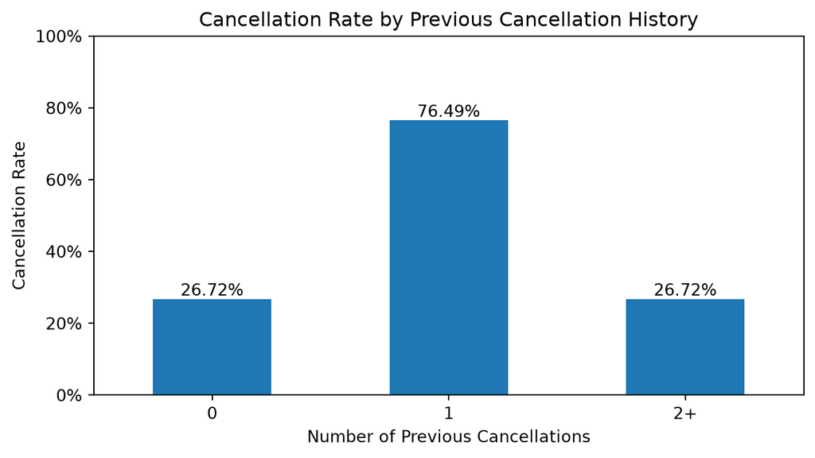

```python
# Group previous cancellations into interpretable categories
previous_cancellation_group = pd.cut(
    train_df["previous_cancellations"],
    bins=[-1, 0, 1, np.inf],
    labels=["0", "1", "2+"]
)

previous_cancellation_summary = (
    train_df.groupby(
        previous_cancellation_group,
        observed=False
    )["is_canceled"]
    .agg(
        bookings="size",
        cancellation_rate="mean"
    )
)

display(previous_cancellation_summary)

# Plot cancellation rate by previous cancellation history
ax = previous_cancellation_summary["cancellation_rate"].plot(
    kind="bar",
    figsize=(7, 4),
    xlabel="Number of Previous Cancellations",
    ylabel="Cancellation Rate",
    title="Cancellation Rate by Previous Cancellation History",
    rot=0
)

ax.yaxis.set_major_formatter(PercentFormatter(1))
ax.set_ylim(0, 1)

for i, rate in enumerate(previous_cancellation_summary["cancellation_rate"]):
    ax.text(
        i,
        rate + 0.01,
        f"{rate:.2%}",
        ha="center"
    )



plt.tight_layout()
plt.show()
```

Previous cancellation history showed a non-linear relationship with the response. Bookings with exactly one previous cancellation had a highest cancellation rate of 76.49%, compared with approximately 26.72% for both bookings with no previous cancellations and those with two or more. This suggests that the predictive information is concentrated in the one-cancellation group rather than increasing steadily with the number of previous cancellations. However, the two-or-more group contained only 232 bookings, so it may have less stable estimates.

### Previous Non-Canceled Bookings

| previous_bookings_not_canceled | bookings | cancellation_rate |
| --- | --- | --- |
| 0 | 66933 | 0.284658 |
| 1 | 1199 | 0.047540 |
| 2–5 | 1044 | 0.059387 |
| 6+ | 605 | 0.056198 |

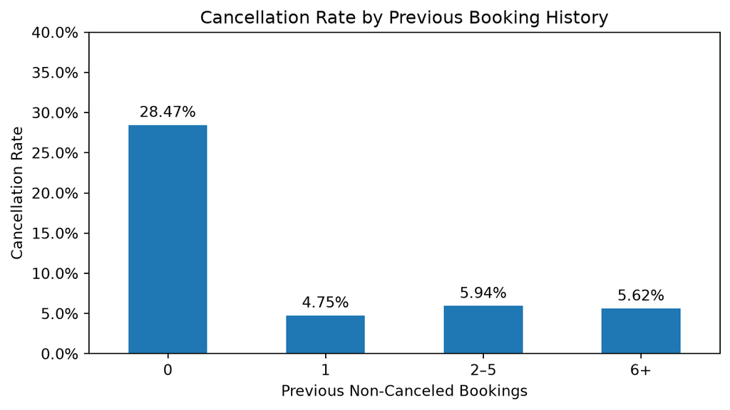

```python
# Group previous non-canceled bookings into interpretable categories
previous_booking_group = pd.cut(
    train_df["previous_bookings_not_canceled"],
    bins=[-1, 0, 1, 5, np.inf],
    labels=["0", "1", "2–5", "6+"]
)

previous_booking_summary = (
    train_df.groupby(
        previous_booking_group,
        observed=False
    )["is_canceled"]
    .agg(
        bookings="size",
        cancellation_rate="mean"
    )
)

display(previous_booking_summary)

# Plot cancellation rate by previous booking history
ax = previous_booking_summary["cancellation_rate"].plot(
    kind="bar",
    figsize=(7, 4),
    xlabel="Previous Non-Canceled Bookings",
    ylabel="Cancellation Rate",
    title="Cancellation Rate by Previous Booking History",
    rot=0
)

ax.yaxis.set_major_formatter(PercentFormatter(1))
ax.set_ylim(0, 0.4)
for i, rate in enumerate(previous_booking_summary["cancellation_rate"]):
    ax.text(
        i,
        rate + 0.01,
        f"{rate:.2%}",
        ha="center"
    )


plt.tight_layout()
plt.show()
```

Previous non-canceled booking history showed a strong relationship with the response. Bookings with no such history had a cancellation rate of 28.47%, compared with 4.75%, 5.94%, and 5.62% for the one, two-to-five, and six-or-more groups, respectively. Because the three positive-count groups had similar rates, the main distinction appears to be whether any previous non-canceled booking existed rather than the exact number. Therefore, we retain the original count and add a binary has_prior_non_canceled_booking feature to capture the distinction between bookings with and without prior non-canceled booking history.

### Special Requests

| total_of_special_requests | bookings | cancellation_rate |
| --- | --- | --- |
| 0 | 35112 | 0.331539 |
| 1 | 23154 | 0.224065 |
| 2 | 9341 | 0.216893 |
| 3+ | 2174 | 0.161454 |

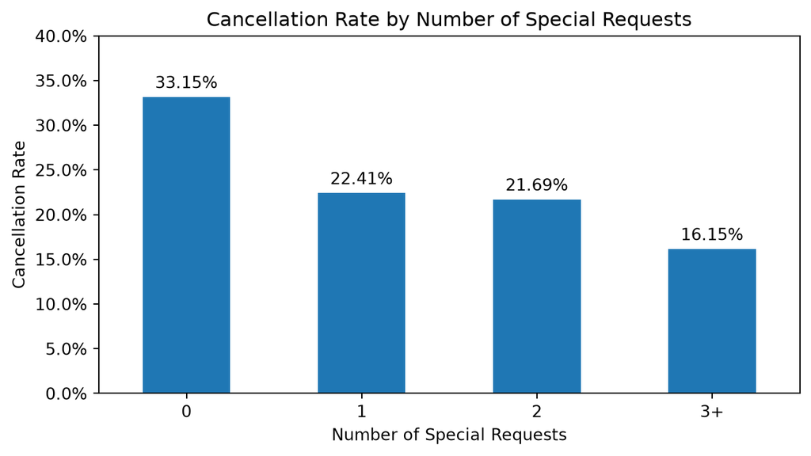

```python
# Group the number of special requests into interpretable categories
special_request_group = pd.cut(
    train_df["total_of_special_requests"],
    bins=[-1, 0, 1, 2, np.inf],
    labels=["0", "1", "2", "3+"]
)

special_request_summary = (
    train_df.groupby(
        special_request_group,
        observed=False
    )["is_canceled"]
    .agg(
        bookings="size",
        cancellation_rate="mean"
    )
)

display(special_request_summary)

# Plot cancellation rate by number of special requests
ax = special_request_summary["cancellation_rate"].plot(
    kind="bar",
    figsize=(7, 4),
    xlabel="Number of Special Requests",
    ylabel="Cancellation Rate",
    title="Cancellation Rate by Number of Special Requests",
    rot=0
)

ax.yaxis.set_major_formatter(PercentFormatter(1))
ax.set_ylim(0, 0.4)

for i, rate in enumerate(special_request_summary["cancellation_rate"]):
    ax.text(
        i,
        rate + 0.01,
        f"{rate:.2%}",
        ha="center"
    )



plt.tight_layout()
plt.show()
```

Cancellation rates decreased as the number of special requests increased. Bookings with no special requests had a cancellation rate of 33.15%, compared with 22.41% for one request, 21.69% for two requests, and 16.15% for three or more requests. Most of the reduction occurred between zero and at least one request, while the rates for one and two requests were similar. This suggests a nonlinear relationship in which the presence of any special request may contain more predictive information than each additional request. The original count will be retained, while a binary `has_special_request` feature may also be evaluated during feature engineering.

### Booking Changes

| booking_changes | bookings | cancellation_rate |
| --- | --- | --- |
| 0 | 57165 | 0.302090 |
| 1 | 8660 | 0.137298 |
| 2 | 2809 | 0.199715 |
| 3+ | 1147 | 0.163034 |

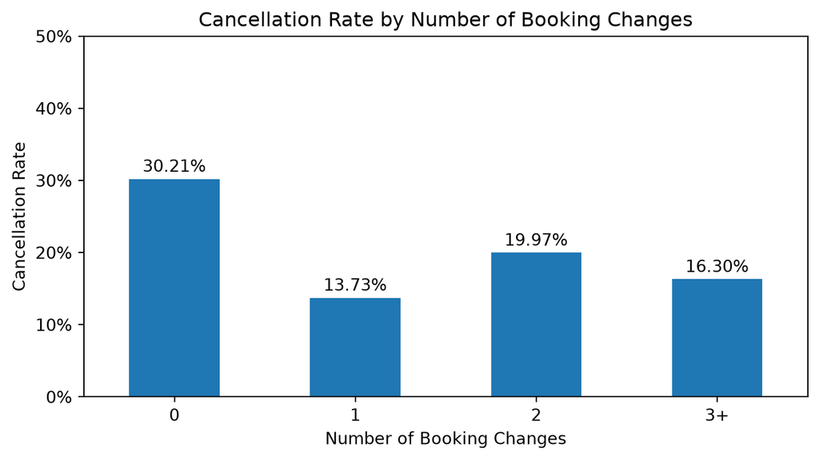

```python
# Group booking changes into interpretable categories
booking_change_group = pd.cut(
    train_df["booking_changes"],
    bins=[-1, 0, 1, 2, np.inf],
    labels=["0", "1", "2", "3+"]
)

booking_change_summary = (
    train_df.groupby(
        booking_change_group,
        observed=False
    )["is_canceled"]
    .agg(
        bookings="size",
        cancellation_rate="mean"
    )
)

display(booking_change_summary)

# Plot cancellation rate by number of booking changes
ax = booking_change_summary["cancellation_rate"].plot(
    kind="bar",
    figsize=(7, 4),
    xlabel="Number of Booking Changes",
    ylabel="Cancellation Rate",
    title="Cancellation Rate by Number of Booking Changes",
    rot=0
)

ax.yaxis.set_major_formatter(PercentFormatter(1))
ax.set_ylim(0, 0.5)

for i, rate in enumerate(booking_change_summary["cancellation_rate"]):
    ax.text(
        i,
        rate + 0.01,
        f"{rate:.2%}",
        ha="center"
    )

plt.tight_layout()
plt.show()
```

`booking_changes` showed a strong but non-monotonic relationship with cancellation. Bookings with no recorded changes had a cancellation rate of 30.21%, compared with 13.73% for one change, 19.97% for two changes, and 16.30% for three or more changes. The main distinction was therefore between bookings with no changes and those with at least one change, rather than a consistent pattern across the number of changes. Because booking changes may occur after the initial reservation, the eligibility of this variable for modeling will depend on the intended prediction time.

### Market Segment

| market_segment | bookings | cancellation_rate |
| --- | --- | --- |
| Corporate | 3367 | 0.120879 |
| Complementary | 544 | 0.128676 |
| Direct | 9425 | 0.146631 |
| Offline TA/TO | 11082 | 0.148078 |
| Aviation | 191 | 0.219895 |
| Groups | 3938 | 0.272727 |
| Online TA | 41232 | 0.353803 |
| Undefined | 2 | 1.000000 |

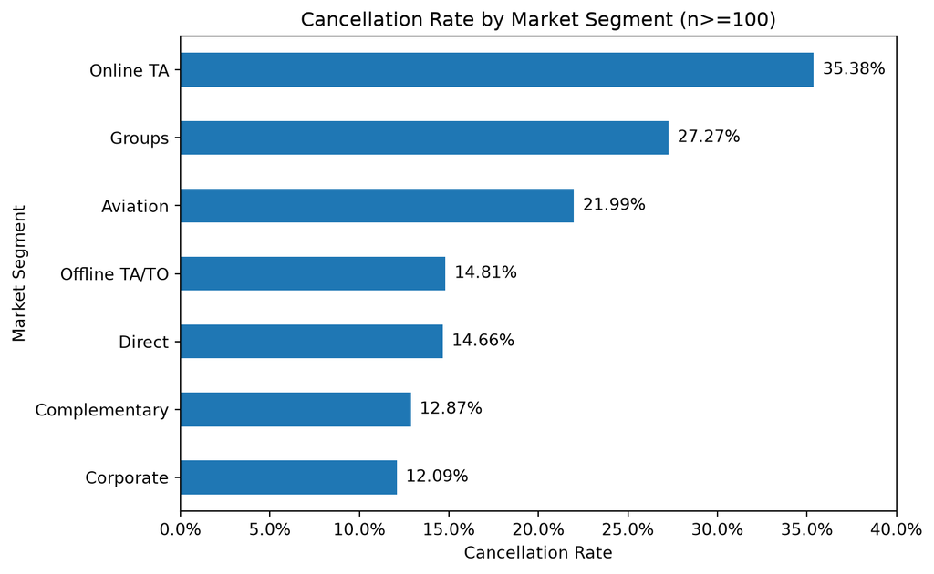

```python
# Summarize cancellation rates by market segment
market_segment_summary = (
    train_df.groupby("market_segment")["is_canceled"]
    .agg(
        bookings="size",
        cancellation_rate="mean"
    )
    .sort_values("cancellation_rate")
)

display(market_segment_summary)


# Exclude extremely small categories from the visualization only
market_segment_plot = market_segment_summary[
    market_segment_summary["bookings"] >= 100
]


# Plot cancellation rate by market segment
ax = market_segment_plot["cancellation_rate"].plot(
    kind="barh",
    figsize=(8, 5),
    xlabel="Cancellation Rate",
    ylabel="Market Segment",
    title="Cancellation Rate by Market Segment (n>=100)"
)


ax.xaxis.set_major_formatter(PercentFormatter(1))
ax.set_xlim(0, 0.4)

for i, rate in enumerate(market_segment_plot["cancellation_rate"]):
    ax.text(rate + 0.005, i, f"{rate:.2%}", va="center")


plt.tight_layout()
plt.show()
```

Cancellation rates differed substantially across market segments. Online TA represented the largest segment and had the highest cancellation rate among adequately represented categories at 35.38%, followed by Groups at 27.27% and Aviation at 21.99%. In contrast, Corporate, Complementary, Direct, and Offline TA/TO bookings had cancellation rates between approximately 12% and 15%. Although the Undefined category had a 100% cancellation rate, it contained only two bookings and therefore did not provide a reliable estimate. Overall, market_segment appears to contain useful predictive information and will be retained as a categorical predictor. Its relationship with deposit_type will be examined later because the unusually high cancellation rate for non-refundable bookings may be concentrated within particular market segments.

### Required Car Parking Spaces

| required_car_parking_spaces | bookings | cancellations | cancellation_rate |
| --- | --- | --- | --- |
| 0 | 63914 | 19206 | 0.300498 |
| 1 | 5843 | 0 | 0.000000 |
| 2 | 20 | 0 | 0.000000 |
| 3 | 3 | 0 | 0.000000 |
| 8 | 1 | 0 | 0.000000 |

| required_car_parking_spaces | bookings | cancellation_rate |
| --- | --- | --- |
| False | 63914 | 0.300498 |
| True | 5867 | 0.000000 |

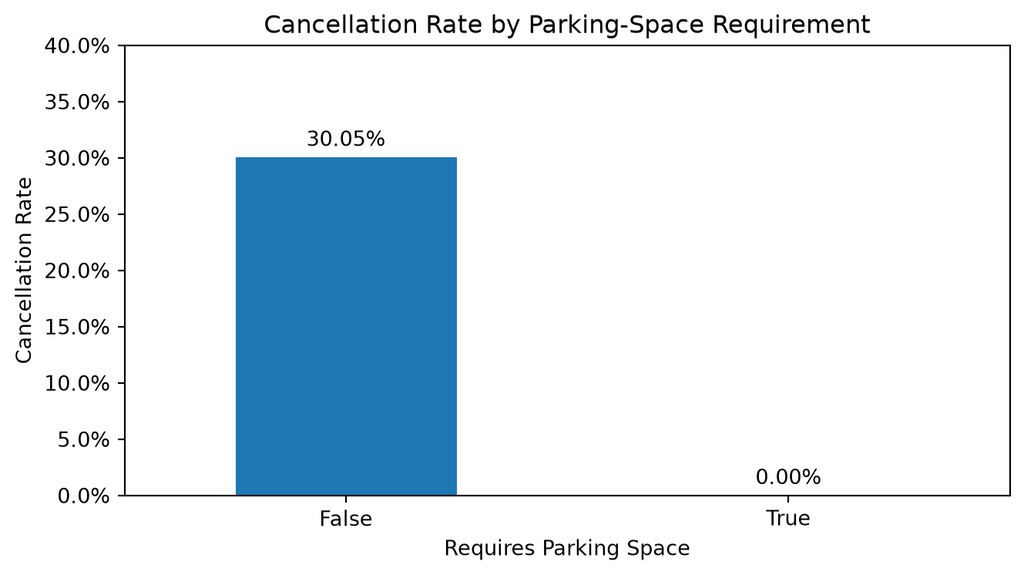

```python
# Audit the original parking-space categories
parking_raw_audit = (
    train_df.groupby("required_car_parking_spaces")["is_canceled"]
    .agg(
        bookings="size",
        cancellations="sum",
        cancellation_rate="mean"
    )
)

display(parking_raw_audit)

# More than 99% of positive values are 1, so pool sparse
# positive categories into a single binary indicator
has_parking_request = train_df["required_car_parking_spaces"] > 0

parking_summary = (
    train_df.groupby(has_parking_request)["is_canceled"]
    .agg(bookings="size", cancellation_rate="mean")
)

display(parking_summary)

# Plot cancellation rate by parking-space requirement
ax = parking_summary["cancellation_rate"].plot(
    kind="bar",
    figsize=(7, 4),
    xlabel="Requires Parking Space",
    ylabel="Cancellation Rate",
    title="Cancellation Rate by Parking-Space Requirement",
    rot=0
)
ax.yaxis.set_major_formatter(PercentFormatter(1))
ax.set_ylim(0, 0.4)

for i, rate in enumerate(parking_summary["cancellation_rate"]):
    ax.text(i, rate + 0.01, f"{rate:.2%}", ha="center")

plt.tight_layout()
plt.show()
```

Parking-space requirements exhibited complete separation from the response. None of the 5,867 training bookings requiring at least one parking space were canceled, compared with a cancellation rate of 30.05% among bookings requiring no parking space. The dataset documentation indicates that this variable may incorporate information from the booking change log up to the day before arrival rather than exclusively information recorded at the initial reservation. Because the intended prediction point is the time of booking, the variable may contain outcome-dependent operational information. It was therefore excluded from the modeling feature set to avoid potentially optimistic performance.

### ADR (Adjusted)

| is_canceled | count | mean | std | min | 25% | 50% | 75% | max |
| --- | --- | --- | --- | --- | --- | --- | --- | --- |
| 0 | 50119.0 | 103.035272 | 50.359165 | 0.0 | 68.69 | 95.00 | 129.6 | 510.0 |
| 1 | 19184.0 | 117.571179 | 51.644000 | 0.0 | 81.00 | 109.65 | 144.0 | 437.0 |

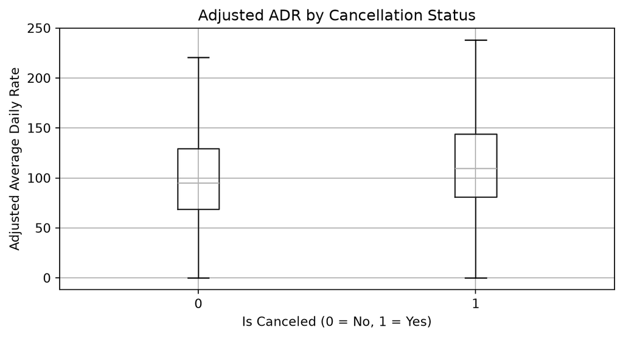

```python
# Compare adr_adj distributions by cancellation status
adr_summary = train_df.groupby("is_canceled")["adr_adj"].describe()
display(adr_summary)

# Visualize the distribution

ax = train_df.boxplot(
    column="adr_adj",
    by="is_canceled",
    figsize=(7, 4),
    showfliers=False # Hide fliers
)



plt.suptitle("")
ax.set_title("Adjusted ADR by Cancellation Status")
ax.set_xlabel("Is Canceled (0 = No, 1 = Yes)")
ax.set_ylabel("Adjusted Average Daily Rate")


plt.tight_layout()
plt.show()
```

Canceled bookings had higher adjusted ADRs, with a median of 109.65 and a mean of 117.57, compared with 95.00 and 103.04 for non-canceled bookings. Although the distributions overlapped substantially, this upward shift suggests that `adr_adj` may provide useful predictive information. The summary statistics and boxplot use non-missing values of adr_adj. Outlier markers are hidden for readability, without excluding additional values from the calculations.

### Hotel Type

| hotel | bookings | cancellation_rate |
| --- | --- | --- |
| City Hotel | 42669 | 0.301577 |
| Resort Hotel | 27112 | 0.233771 |

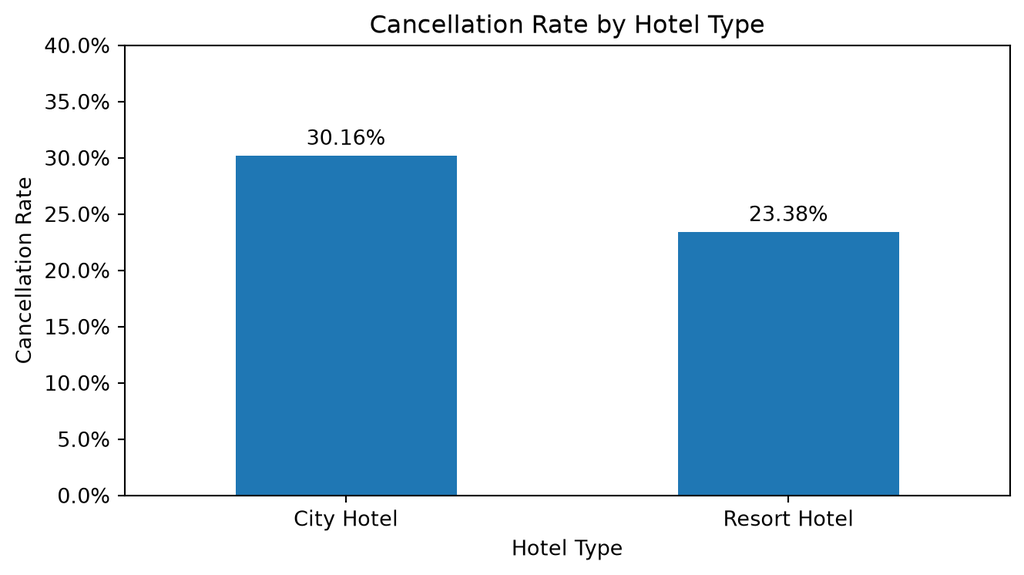

```python
# Summarize cancellation rates by hotel type
hotel_summary = (
    train_df.groupby("hotel")["is_canceled"]
    .agg(
        bookings="size",
        cancellation_rate="mean"
    )
)

display(hotel_summary)

# Plot cancellation rate by hotel type
ax = hotel_summary["cancellation_rate"].plot(
    kind="bar",
    figsize=(7, 4),
    xlabel="Hotel Type",
    ylabel="Cancellation Rate",
    title="Cancellation Rate by Hotel Type",
    rot=0
)

ax.yaxis.set_major_formatter(PercentFormatter(1))
ax.set_ylim(0, 0.4)

for i, rate in enumerate(hotel_summary["cancellation_rate"]):
    ax.text(
        i,
        rate + 0.01,
        f"{rate:.2%}",
        ha="center"
    )

plt.tight_layout()
plt.show()
```

City Hotel bookings had a cancellation rate of 30.16%, compared with 23.38% for Resort Hotel bookings。 Both hotels contributed substantial numbers of observations, with 42,669 City Hotel bookings and 27,112 Resort Hotel bookings in the training set. Although cancellation was more common at the City Hotel, this comparison does not account for differences in customer types, booking channels, or lead times.

### Customer Type

| customer_type | bookings | cancellation_rate |
| --- | --- | --- |
| Group | 421 | 0.092637 |
| Transient-Party | 9366 | 0.152146 |
| Contract | 2510 | 0.164542 |
| Transient | 57484 | 0.301458 |

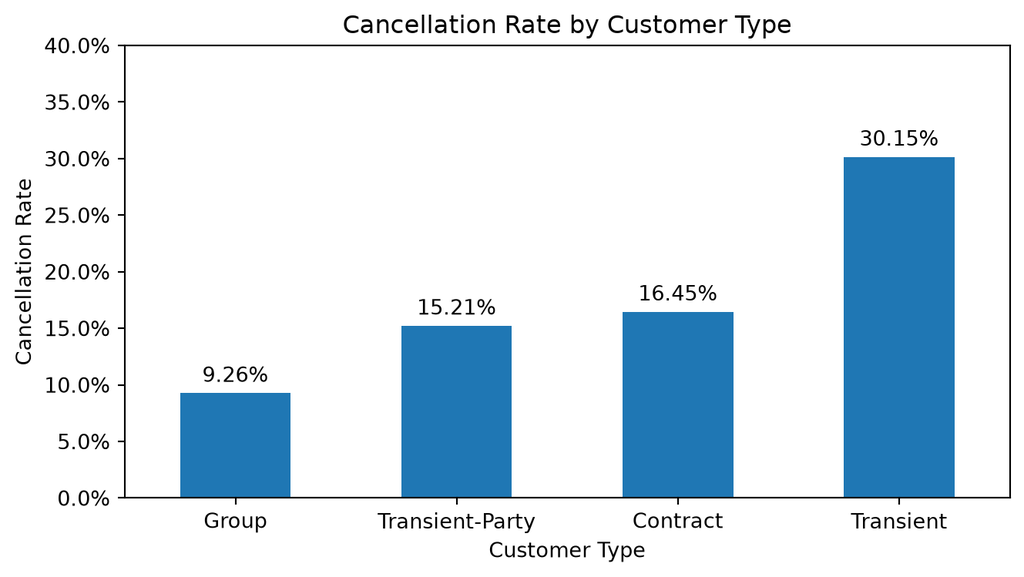

```python
# Summarize cancellation rates by customer type
customer_type_summary = (
    train_df.groupby("customer_type")["is_canceled"]
    .agg(
        bookings="size",
        cancellation_rate="mean"
    )
    .sort_values("cancellation_rate")
)

display(customer_type_summary)

# Plot cancellation rate by customer type
ax = customer_type_summary["cancellation_rate"].plot(
    kind="bar",
    figsize=(7, 4),
    xlabel="Customer Type",
    ylabel="Cancellation Rate",
    title="Cancellation Rate by Customer Type",
    rot=0
)

ax.yaxis.set_major_formatter(PercentFormatter(1))
ax.set_ylim(0, 0.4)

for i, rate in enumerate(customer_type_summary["cancellation_rate"]):
    ax.text(
        i,
        rate + 0.01,
        f"{rate:.2%}",
        ha="center"
    )

plt.tight_layout()
plt.show()
```

Cancellation rates varied across customer types. Transient bookings had the highest rate at 30.15%, compared with 16.45% for Contract and 15.21% for Transient-Party bookings. Group bookings had the lowest rate at 9.26%, but this category contained only 421 observations, so its estimate may be less stable. The main distinction was between Transient bookings and the other customer types, while Contract and Transient-Party bookings had similar rates.

## Stratified Analysis

```python
# Group previous cancellations using the same categories as before
previous_cancel_group = pd.cut(
    train_df["previous_cancellations"],
    bins=[-1, 0, 1, np.inf],
    labels=["0", "1", "2+"]
)

# Separate bookings by whether there is any prior non-canceled booking
previous_stay_group = pd.cut(
    train_df["previous_bookings_not_canceled"],
    bins=[-1, 0, np.inf],
    labels=["No prior non-canceled bookings", "Has prior non-canceled bookings"]
)

# Summarize cancellation outcomes within each history combination
history_summary = (
    train_df.groupby(
        [
            previous_cancel_group.rename("previous_cancellations"),
            previous_stay_group.rename("prior_booking_history")
        ],
        observed=True
    )["is_canceled"]
    .agg(
        bookings="size",
        cancellations="sum",
        cancellation_rate="mean"
    )
)

# Compare sample sizes
display(
    history_summary["bookings"]
    .unstack("prior_booking_history")
)

# Compare cancellation rates (%)
display(
    (
        history_summary["cancellation_rate"]
        .unstack("prior_booking_history") * 100
    ).round(2)
)
```

| prior_booking_history previous_cancellations | No prior non-canceled bookings | Has prior non-canceled bookings |
| --- | --- | --- |
| 0 | 66084 | 2338 |
| 1 | 820 | 307 |
| 2+ | 29 | 203 |

| prior_booking_history previous_cancellations | No prior non-canceled bookings | Has prior non-canceled bookings |
| --- | --- | --- |
| 0 | 27.58 | 2.48 |
| 1 | 98.17 | 18.57 |
| 2+ | 82.76 | 18.72 |

The lower cancellation rate for guests with 2+ previous cancellations (26.72%) compared with guests with exactly one (76.49%) appears related to their non-canceled booking history. Guests in the 2+ group were considerably more likely to also have prior non-canceled bookings, suggesting many are repeat guests whose overall booking pattern signals reliability, offsetting the risk implied by their cancellation count alone. This reinforces the earlier finding that the presence of any prior non-canceled booking is strongly associated with lower cancellation risk.

### Market Segment and Deposit Type Interaction

```python
# Booking counts by market segment and deposit type
segment_deposit_counts = pd.crosstab(
    train_df["market_segment"],
    train_df["deposit_type"]
)

print("Booking counts")
display(segment_deposit_counts)

# Deposit-type composition within each market segment (%)
segment_deposit_composition = pd.crosstab(
    train_df["market_segment"],
    train_df["deposit_type"],
    normalize="index"
) * 100

print("Deposit-type composition within each market segment (%)")
display(segment_deposit_composition.round(2))

# Cancellation rates by market segment and deposit type (%)
segment_deposit_cxlrate = pd.crosstab(
    train_df["market_segment"],
    train_df["deposit_type"],
    values=train_df["is_canceled"],
    aggfunc="mean"
) * 100

print("Cancellation rates (%)")
display(segment_deposit_cxlrate.round(2))
```

```
Booking counts
```

| deposit_type market_segment | No Deposit | Non Refund | Refundable |
| --- | --- | --- | --- |
| Aviation | 191 | 0 | 0 |
| Complementary | 544 | 0 | 0 |
| Corporate | 3316 | 48 | 3 |
| Direct | 9412 | 8 | 5 |
| Groups | 3329 | 547 | 62 |
| Offline TA/TO | 10851 | 227 | 4 |
| Online TA | 41205 | 15 | 12 |
| Undefined | 2 | 0 | 0 |

```
Deposit-type composition within each market segment (%)
```

| deposit_type market_segment | No Deposit | Non Refund | Refundable |
| --- | --- | --- | --- |
| Aviation | 100.00 | 0.00 | 0.00 |
| Complementary | 100.00 | 0.00 | 0.00 |
| Corporate | 98.49 | 1.43 | 0.09 |
| Direct | 99.86 | 0.08 | 0.05 |
| Groups | 84.54 | 13.89 | 1.57 |
| Offline TA/TO | 97.92 | 2.05 | 0.04 |
| Online TA | 99.93 | 0.04 | 0.03 |
| Undefined | 100.00 | 0.00 | 0.00 |

```
Cancellation rates (%)
```

| deposit_type market_segment | No Deposit | Non Refund | Refundable |
| --- | --- | --- | --- |
| Aviation | 21.99 | NaN | NaN |
| Complementary | 12.87 | NaN | NaN |
| Corporate | 11.28 | 66.67 | 33.33 |
| Direct | 14.62 | 62.50 | 20.00 |
| Groups | 16.31 | 96.16 | 8.06 |
| Offline TA/TO | 13.04 | 98.68 | 50.00 |
| Online TA | 35.35 | 80.00 | 100.00 |
| Undefined | 100.00 | NaN | NaN |

One defining characteristic is that most Non Refund bookings are concentrated in Groups and Offline TA/TO, which account for 64.73% and 26.86% of this deposit category. The remaining bookings come from Corporate (5.68%), Online TA (1.78%), and Direct (0.95%). Within Groups segment, Non Refund bookings make up only 13.89% of bookings, yet have a cancellation rate of 96.16%, far above the 16.31% for No Deposit bookings. This small subset contributes nearly half of the segment’s total cancellations. Offline TA/TO has an even higher Non Refund cancellation rate of 98.68%, but these bookings represent just 2.05% of the segment. Most bookings are instead No Deposit, with a cancellation rate of 13.04%, so the segment’s overall rate remains comparatively low.

## Correlation Analysis

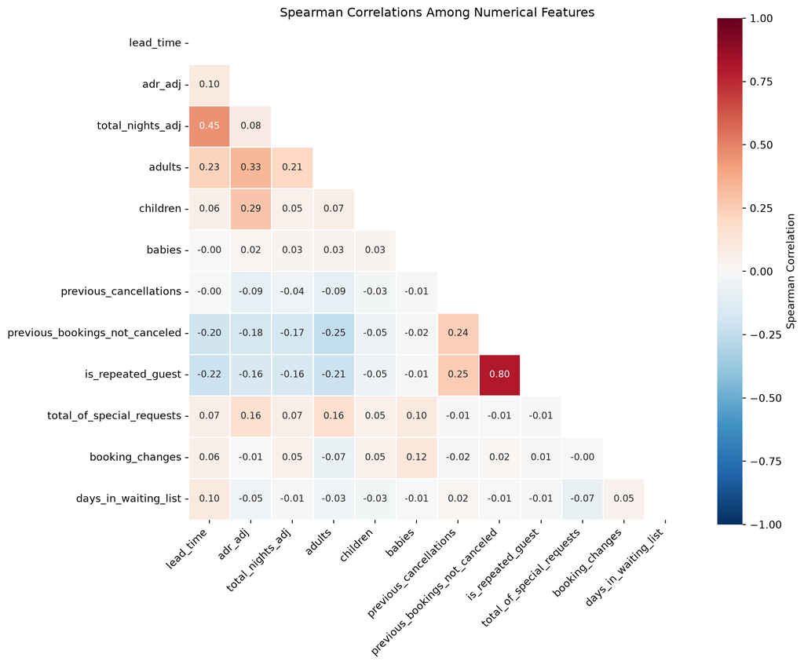

```python
import seaborn as sns

# Select numerical features, excluding IDs and nominal categories
correlation_columns = [
    "lead_time",
    "adr_adj",
    "total_nights_adj",
    "adults",
    "children",
    "babies",
    "previous_cancellations",
    "previous_bookings_not_canceled",
    "is_repeated_guest",
    "total_of_special_requests",
    "booking_changes",
    "days_in_waiting_list"
]

# Calculate Spearman correlations using the training data only
correlation_matrix = (
    train_df[correlation_columns]
    .corr(method="spearman")
)

# Hide the upper triangle because it repeats the lower triangle
mask = np.triu(
    np.ones_like(correlation_matrix, dtype=bool),
    k=0
)

# Plot the correlation matrix
plt.figure(figsize=(11, 9))

ax = sns.heatmap(
    correlation_matrix,
    mask=mask,
    annot=True,
    fmt=".2f",
    annot_kws={"size": 9},
    cmap="RdBu_r",
    vmin=-1,
    vmax=1,
    center=0,
    square=True,
    linewidths=0.5,
    cbar_kws={"label": "Spearman Correlation"}
)

ax.set_title("Spearman Correlations Among Numerical Features")
plt.xticks(rotation=45, ha="right")
plt.yticks(rotation=0)

plt.tight_layout()
plt.show()
```

Most numerical predictors show weak to moderate correlations, suggesting limited redundancy. The main exception is `previous_bookings_not_canceled` and `is_repeated_guest` (ρ = 0.80), since both reflect prior booking history. `lead_time` and `total_nights_adj` are moderately correlated (ρ = 0.45), but not strongly enough to justify removing either variable. We therefore retain these predictors initially and evaluate their usefulness during model validation.

## EDA Summary

The bivariate and stratified analyses reveal several patterns that will guide feature engineering and modeling:

- Cancellation rates increase steadily with `lead_time`, we We use log_lead_time in the primary models to compress its right-skewed distribution.
- `deposit_type` should be considered together with `market_segment`, since Non Refund bookings are concentrated mainly in Groups and Offline TA/TO. An interaction term may be useful for logistic regression. We alse add `non_refund_groups` and `non_refund_offline_ta_to` to represent the two combinations associated with particularly high cancellation rates.
- - `previous_bookings_not_canceled` and `total_of_special_requests` show their largest differences in cancellation rates between zero and positive counts. We retain the original counts and add `has_prior_non_canceled_booking` and `has_special_request` to capture these distinctions.
- The most surprising pattern was found in `previous_cancellations`: bookings with exactly one previous cancellation have a 76.49% cancellation rate, compared with 26.72% for those with two or more. This reversal is partly explained by the much larger proportion of prior non-canceled bookings in the latter group, so both history variables should be interpreted jointly.
- Numerical predictors show limited redundancy overall. The main exception is `is_repeated_guest` and `previous_bookings_not_canceled` (ρ = 0.80). Both variables are retained in the primary model because the modeling pipeline evaluates their joint predictive contribution.
- Cancellations make up approximately 27% of the response. We will preserve this moderately imbalanced distribution through stratified resampling and evaluate performance with ROC AUC and confusion-matrix metrics rather than relying on accuracy alone.
- - The unusually extremenly strong association between `required_car_parking_spaces` and cancellation raises concerns about information availability at booking time. We exclude this variable and its binary version from the primary models. We also exclude `booking_changes` and `has_booking_change`, because they describe changes occurring after the initial reservation.

These findings support targeted feature engineering while retaining potentially useful predictors for model validation.

# Feature Engineering and Preprocessing

Feature engineering and preprocessing are implemented in separate Python modules to keep the analysis reproducible and the report concise. The deterministic feature transformations and their structural validation are defined in `src/feature_engineering.py`, while predictor selection, eligibility checks, imputation, encoding, scaling, and rare-category pooling are defined in `src/preprocessing.py`. The Quarto document imports and applies these functions, reports their validation results, and explains the resulting design matrix.

## Feature Engineering

The following engineered predictors are created:

- `log_lead_time` reduces the strong right skew in `lead_time` and is selected for the primary model.
- `arrival_month_sin` and `arrival_month_cos` represent annual seasonality while treating December and January as adjacent. `arrival_month_num` records the calendar month number but is not selected for the primary models.
- `weekend_night_ratio` measures the proportion of recorded nights occurring on weekends. It remains missing when `total_nights_adj` is missing or nonpositive.
- Binary variables `has_prior_non_canceled_booking`and `has_special_request` capture the distinction between zero and positive counts identified during EDA. Their original count variables are also retained in the primary models.
- `is_family_booking` indicates whether a booking includes at least one child or baby. It remains missing when missing guest counts prevent this determination.
- `previous_cancellations_bucket` represents the non-monotonic pattern across zero, one, and two or more previous cancellations.
- `non_refund_groups` and `non_refund_offline_ta_to` capture the two high-risk combinations of `deposit_type` and `market_segment` identified during EDA.
- `has_booking_change` and `has_parking_request` are also created, but both are excluded from the primary booking-time models.

The validation checks confirm that:

- Feature engineering preserves the number and ordering of observations in both the training and test sets.
- No original predictor is removed.
- All expected engineered predictors are created in both data splits, and the resulting training and test columns match exactly.
- The response `is_canceled` and the previously removed leakage variables do not enter the engineered predictor data.
- All engineered binary indicators contain only 0 and 1 among their observed values. Missing values in `is_family_booking` remain permitted because they will be imputed within the preprocessing pipeline.
- `previous_cancellations_bucket` contains only the intended levels `0`, `1`, and `2+`.

These checks leave 69,781 training observations unchanged and increase the number of available predictors from 31 to 44

```python
from src.feature_engineering import (
    engineer_features,
    validate_engineered_features
)

# Apply deterministic feature engineering
X_train_fe = engineer_features(X_train)
X_test_fe = engineer_features(X_test)

# Run structural checks
validate_engineered_features(
    original=X_train,
    engineered=X_train_fe
)

validate_engineered_features(
    original=X_test,
    engineered=X_test_fe
)

assert X_train_fe.columns.equals(X_test_fe.columns)

print("Feature engineering checks passed.")
print(f"Original predictors: {X_train.shape[1]}")
print(f"Available predictors after engineering: {X_train_fe.shape[1]}")
```

```
Feature engineering checks passed.
Original predictors: 31
Available predictors after engineering: 44
```

## Preprocessing

### Rare-Category Threshold Selection

```python
from src.preprocessing import HIGH_CARDINALITY_COLUMNS

for threshold in [0.001, 0.002, 0.005]:
    print(f"\nThreshold: {threshold:.3%}")

    for column in HIGH_CARDINALITY_COLUMNS:
        counts = X_train_fe[column].value_counts()
        minimum_count = threshold * len(X_train_fe)

        frequent_levels = counts[counts >= minimum_count]
        pooled_count = counts[counts < minimum_count].sum()

        print(
            f"{column}: {len(frequent_levels)} retained levels, "
            f"{pooled_count / len(X_train_fe):.2%} of rows pooled"
        )
```

```
Threshold: 0.100%
agent: 63 retained levels, 4.77% of rows pooled
country: 37 retained levels, 2.55% of rows pooled

Threshold: 0.200%
agent: 40 retained levels, 8.19% of rows pooled
country: 32 retained levels, 3.26% of rows pooled

Threshold: 0.500%
agent: 17 retained levels, 14.78% of rows pooled
country: 20 retained levels, 7.44% of rows pooled
```

A threshold of 0.1% retained 63 `agent` levels and pooled 4.77% of its observations. The 0.5% threshold retained only 17 `agent` levels and pooled 14.78% of the observations, which may result in information loss. The intermediate 0.2% threshold retained 40 `agent` levels and 32 `country` levels while pooling 8.19% and 3.26% of their observations. Therefore, 0.2% was selected as a balance between retaining category-level information and reducing sparse one-hot-encoded columns.

### Preprocessing Pipeline

```python
from src.preprocessing import make_preprocessor, validate_feature_columns, MODEL_COLUMNS


# Confirm that all selected predictors exist and are eligible
validate_feature_columns(X_train_fe)
validate_feature_columns(X_test_fe)

# Fit a temporary preprocessor for structural validation only
preprocessor_check = make_preprocessor(scale_numeric=True)
X_train_processed = preprocessor_check.fit_transform(X_train_fe)

# Retrieve the names of all transformed predictors
processed_feature_names = preprocessor_check.get_feature_names_out()

# Validate the processed design matrix
assert X_train_processed.shape[0] == X_train_fe.shape[0]
assert X_train_processed.shape[1] == len(processed_feature_names)
assert np.isfinite(X_train_processed).all()
assert len(processed_feature_names) == len(set(processed_feature_names))

print("Preprocessing checks passed.")
print(f"Rows: {X_train_processed.shape[0]:,}")
print(f"Predictors before preprocessing: {len(MODEL_COLUMNS)}")
print(f"Predictors after one-hot encoding: {X_train_processed.shape[1]}")
```

```
Preprocessing checks passed.
Rows: 69,781
Predictors before preprocessing: 31
Predictors after one-hot encoding: 134
```

The primary engineered specification selects 31 predictors through explicit column lists. Variables that contain post-booking information, show unexplained separation, or have been superseded by cleaned versions are blocked from the primary design matrix.

The preprocessing pipeline then applies the following steps:

- Missing numerical values are imputed using training-data medians and standardized for scale-sensitive models.
- Binary predictors receive most-frequent imputation but retain their 0/1 representation.
- Low-cardinality categorical predictors were one-hot encoded.
- For high cardinality predictors `agent` and `country`, levels occurring in fewer than 0.2% of the fitted training observations were pooled into an infrequent category. The selected threshold retains 40 `agent` levels and 32 `country` levels in the full training data while pooling 8.19% and 3.26% of their observations.
- Unrecognized categories in validation or test data are handled without refitting the encoder.
- All variables not explicitly assigned to a preprocessing group are removed through `remainder="drop"`.
- The fitted preprocessor here is used only for structural validation. During cross-validation, a fresh preprocessor is fitted within each training fold as part of the model pipeline.

The preprocessing validation confirmed that all 31 selected predictors were present, no predictor was assigned to multiple preprocessing groups, and none of the predefined ineligible variables entered the primary design matrix. The transformation preserved all 69,781 training observations and produced 134 numerical model-matrix columns after one-hot encoding. The resulting matrix contained no missing or infinite values, and all transformed feature names were unique.

# Model Development and Cross-Validation

All candidate models were trained using the same five stratified cross-validation folds. Hyperparameter selection used mean validation ROC AUC as the primary criterion because the response is binary and the cancellation classes are imbalanced. Accuracy, sensitivity, and specificity were also recorded to describe the operating characteristics of each model. For each model, preprocessing was fitted within the corresponding training fold as part of the modeling pipeline.

The tuning grids focused on parameters that control regularization, model complexity, and stochastic sampling. Other implementation settings were held fixed to keep the search computationally feasible and to avoid an excessively large search over highly related parameters. The same scoring metrics and cross-validation folds were used across models to support a consistent comparison.

```python
import src.train_models as train_models
from src.train_models import make_cv, CV_FOLDS

# Create identical cross-validation folds for all candidate models
cv = make_cv(random_state=RANDOM_STATE)
```

## Elastic Net Logistic Regression

```python
elastic_net_path = MODEL_DIR / "elastic_net_search_v2.joblib"

# Train and save the search, or load the existing fitted search
if RETRAIN_MODELS or not elastic_net_path.exists():
    elastic_net_search = train_models.make_elastic_net_search(
        random_state=RANDOM_STATE,
        n_jobs=8
    )

    _ = elastic_net_search.fit(X_train_fe, y_train)

    dump(elastic_net_search, elastic_net_path, compress=3)

    print("Elastic Net trained and saved.")
else:
    elastic_net_search = load(elastic_net_path)
    print("Saved Elastic Net search loaded.")


elastic_net_results = (
    pd.DataFrame(elastic_net_search.cv_results_)
    [[
        "param_model__C",
        "param_model__l1_ratio",
        "mean_train_roc_auc",
        "mean_test_roc_auc",
        "std_test_roc_auc",
        "mean_test_accuracy",
        "mean_test_sensitivity",
        "mean_test_specificity",
    ]]
    .rename(columns={
        "mean_train_roc_auc": "mean_cv_train_roc_auc",
        "mean_test_roc_auc": "mean_cv_validation_roc_auc",
        "std_test_roc_auc": "std_cv_validation_roc_auc",
        "mean_test_accuracy": "mean_cv_validation_accuracy",
        "mean_test_sensitivity": "mean_cv_validation_sensitivity",
        "mean_test_specificity": "mean_cv_validation_specificity",
    })
    .sort_values("mean_cv_validation_roc_auc", ascending=False)
    .reset_index(drop=True)
)

display(
    elastic_net_results.head(6)
    .style
    .format(precision=4)
    .hide(axis="index")
)
best_model = (
    elastic_net_search
    .best_estimator_
    .named_steps["model"]
)

print(f"Selected parameters: {elastic_net_search.best_params_}")
print(f"Best mean CV ROC AUC: {elastic_net_search.best_score_:.4f}")
print(f"Maximum iterations: {best_model.max_iter}")
print(f"Iterations used: {best_model.n_iter_[0]}")
```

```
Saved Elastic Net search loaded.
```

| param_model__C | param_model__l1_ratio | mean_cv_train_roc_auc | mean_cv_validation_roc_auc | std_cv_validation_roc_auc | mean_cv_validation_accuracy | mean_cv_validation_sensitivity | mean_cv_validation_specificity |
| --- | --- | --- | --- | --- | --- | --- | --- |
| 100.0000 | 1.0000 | 0.8531 | 0.8516 | 0.0037 | 0.8028 | 0.5115 | 0.9134 |
| 100.0000 | 0.5000 | 0.8531 | 0.8516 | 0.0037 | 0.8028 | 0.5115 | 0.9134 |
| 1000.0000 | 1.0000 | 0.8531 | 0.8516 | 0.0037 | 0.8028 | 0.5115 | 0.9134 |
| 1000.0000 | 0.5000 | 0.8531 | 0.8516 | 0.0037 | 0.8028 | 0.5115 | 0.9134 |
| 1000.0000 | 0.0000 | 0.8531 | 0.8516 | 0.0037 | 0.8028 | 0.5115 | 0.9134 |
| 1000.0000 | 0.2000 | 0.8531 | 0.8516 | 0.0037 | 0.8028 | 0.5115 | 0.9134 |

```
Selected parameters: {'model__C': 100, 'model__l1_ratio': 1.0}
Best mean CV ROC AUC: 0.8516
Maximum iterations: 1000
Iterations used: 354
```

The regularized logistic regression pipeline applies median imputation, standardization of numerical predictors and categorical encoding. Five-fold cross-validation searches over `C ∈ {0.01, 0.1, 1, 10, 100, 1000}` and `l1_ratio ∈ {0, 0.2, 0.5, 1}`. Smaller `C` values impose stronger regularization, while `l1_ratio` determines the penalty: 0 gives L2, 1 gives L1, and intermediate values combine both. Since scikit-learn 1.8 deprecates `penalty`, the implementation specifies regularization through `C` and `l1_ratio`, without explicitly setting `penalty="elasticnet"`.

The selected configuration, `C = 100` and `l1_ratio = 1.0`, corresponds to L1-regularized logistic regression. It achieves a mean validation ROC AUC of 0.8516 (SD 0.0037), accuracy of 0.8028, sensitivity of 0.5115, and specificity of 0.9134.

Several configurations at large `C` values produce nearly identical validation AUCs, so the selected L1 configuration offers little practical advantage over nearby alternatives. The fitted estimator stops after 354 of 1,000 permitted iterations, indicating that it does not reach the iteration limit.

## Pruned Decision Tree

```python
decision_tree_path = MODEL_DIR / "decision_tree_search.joblib"

if RETRAIN_MODELS or not decision_tree_path.exists():
    decision_tree_search = train_models.make_decision_tree_search(
        random_state=RANDOM_STATE,
        n_jobs=8
    )
    _ = decision_tree_search.fit(X_train_fe, y_train)

    dump(decision_tree_search, decision_tree_path, compress=3)
    print("Decision Tree trained and saved.")
else:
    decision_tree_search = load(decision_tree_path)
    print("Saved Decision Tree search loaded.")


decision_tree_results = (
    pd.DataFrame(decision_tree_search.cv_results_)
    [[
        "param_model__max_depth",
        "param_model__min_samples_leaf",
        "param_model__ccp_alpha",
        "mean_train_roc_auc",
        "mean_test_roc_auc",
        "std_test_roc_auc",
        "mean_test_accuracy",
        "mean_test_sensitivity",
        "mean_test_specificity",
    ]]
    .rename(columns={
        "mean_train_roc_auc": "mean_cv_train_roc_auc",
        "mean_test_roc_auc": "mean_cv_validation_roc_auc",
        "std_test_roc_auc": "std_cv_validation_roc_auc",
        "mean_test_accuracy": "mean_cv_validation_accuracy",
        "mean_test_sensitivity": "mean_cv_validation_sensitivity",
        "mean_test_specificity": "mean_cv_validation_specificity",
    })
    .sort_values("mean_cv_validation_roc_auc", ascending=False)
    .reset_index(drop=True)
)

display(
    decision_tree_results.head(5)
    .style
    .format(precision=4)
    .hide(axis="index")
)

best_tree = (
    decision_tree_search
    .best_estimator_
    .named_steps["model"]
)

print(f"Best parameters: {decision_tree_search.best_params_}")
print(f"Best mean CV ROC AUC: {decision_tree_search.best_score_:.4f}")
print(f"Final tree depth: {best_tree.get_depth()}")
print(f"Final number of leaves: {best_tree.get_n_leaves()}")
```

```
Saved Decision Tree search loaded.
```

| param_model__max_depth | param_model__min_samples_leaf | param_model__ccp_alpha | mean_cv_train_roc_auc | mean_cv_validation_roc_auc | std_cv_validation_roc_auc | mean_cv_validation_accuracy | mean_cv_validation_sensitivity | mean_cv_validation_specificity |
| --- | --- | --- | --- | --- | --- | --- | --- | --- |
| None | 20 | 0.0001 | 0.8876 | 0.8777 | 0.0031 | 0.8232 | 0.6056 | 0.9058 |
| None | 100 | 0.0000 | 0.8861 | 0.8708 | 0.0030 | 0.8148 | 0.5861 | 0.9017 |
| None | 100 | 0.0000 | 0.8875 | 0.8703 | 0.0031 | 0.8146 | 0.5850 | 0.9018 |
| 8 | 20 | 0.0000 | 0.8754 | 0.8692 | 0.0031 | 0.8138 | 0.5917 | 0.8982 |
| 8 | 20 | 0.0000 | 0.8758 | 0.8692 | 0.0031 | 0.8138 | 0.5915 | 0.8982 |

```
Best parameters: {'model__ccp_alpha': 0.0001, 'model__max_depth': None, 'model__min_samples_leaf': 20}
Best mean CV ROC AUC: 0.8777
Final tree depth: 18
Final number of leaves: 156
```

The decision tree search evaluated 48 parameter combinations using five-fold cross-validation. And the searches over parameters values included `max_depth ∈ {4, 6, 8, None}`, `min_samples_leaf ∈ {20, 100, 300}`, and `ccp_alpha ∈ {0, 0.00001, 0.0001, 0.001}`. `max_depth` limits the maximum number of splitting levels, `min_samples_leaf` prevents leaves from being formed from very small groups of observations, and `ccp_alpha` controls cost-complexity pruning. The configuration with the highest mean validation ROC AUC was selected.

The selected configuration was: `max_depth = None`, `min_samples_leaf = 20`, `ccp_alpha = 0.0001`

Although the maximum depth was not explicitly bounded, the minimum leaf size and positive pruning parameter constrained the fitted tree. The final fitted tree had depth 18 and 156 leaves. Its mean validation ROC AUC was 0.8777, with a standard deviation of 0.0031. The mean validation accuracy was 0.8232, while the mean sensitivity and specificity were 0.6056 and 0.9058.

This model provided a nonlinear baseline while retaining a relatively interpretable tree structure. The difference between its training and validation AUC was smaller than that of the ensemble models, suggesting less overfitting but also lower predictive performance.

## Random Forest

```python
import src.train_models as train_models


random_forest_path = (
    MODEL_DIR / "random_forest_search.joblib"
)

if RETRAIN_MODELS or not random_forest_path.exists():
    random_forest_search = (
        train_models.make_random_forest_search(
            random_state=RANDOM_STATE,
            n_jobs=8
        )
    )

    _ = random_forest_search.fit(
        X_train_fe,
        y_train
    )

    dump(
        random_forest_search,
        random_forest_path,
        compress=3
    )

    print("Random Forest trained and saved.")
else:
    random_forest_search = load(
        random_forest_path
    )

    print("Saved Random Forest search loaded.")


random_forest_results = (
    pd.DataFrame(
        random_forest_search.cv_results_
    )
    [[
        "param_model__max_depth",
        "param_model__min_samples_leaf",
        "param_model__max_features",
        "mean_train_roc_auc",
        "mean_test_roc_auc",
        "std_test_roc_auc",
        "mean_test_accuracy",
        "mean_test_sensitivity",
        "mean_test_specificity",
    ]]
    .rename(columns={
        "mean_train_roc_auc": "mean_cv_train_roc_auc",
        "mean_test_roc_auc": "mean_cv_validation_roc_auc",
        "std_test_roc_auc": "std_cv_validation_roc_auc",
        "mean_test_accuracy": "mean_cv_validation_accuracy",
        "mean_test_sensitivity": "mean_cv_validation_sensitivity",
        "mean_test_specificity": "mean_cv_validation_specificity",
    })
    .sort_values("mean_cv_validation_roc_auc", ascending=False)
    .reset_index(drop=True)
)

display(
    random_forest_results.head(10)
    .style
    .format(precision=4)
    .hide(axis="index")
)



best_forest = (
    random_forest_search
    .best_estimator_
    .named_steps["model"]
)

tree_depths = [
    tree.get_depth()
    for tree in best_forest.estimators_
]

print(
    f"Best parameters: "
    f"{random_forest_search.best_params_}"
)
print(
    f"Best mean CV ROC AUC: "
    f"{random_forest_search.best_score_:.4f}"
)
print(
    f"Number of trees: "
    f"{best_forest.n_estimators}"
)
print(
    f"Mean tree depth: "
    f"{np.mean(tree_depths):.1f}"
)
print(
    f"Maximum tree depth: "
    f"{np.max(tree_depths)}"
)
```

```
Saved Random Forest search loaded.
```

| param_model__max_depth | param_model__min_samples_leaf | param_model__max_features | mean_cv_train_roc_auc | mean_cv_validation_roc_auc | std_cv_validation_roc_auc | mean_cv_validation_accuracy | mean_cv_validation_sensitivity | mean_cv_validation_specificity |
| --- | --- | --- | --- | --- | --- | --- | --- | --- |
| 22 | 5 | 0.3000 | 0.9630 | 0.9000 | 0.0024 | 0.8382 | 0.6275 | 0.9181 |
| 18 | 5 | 0.3000 | 0.9499 | 0.8987 | 0.0025 | 0.8367 | 0.6185 | 0.9196 |
| 22 | 10 | 0.3000 | 0.9418 | 0.8976 | 0.0026 | 0.8354 | 0.6154 | 0.9189 |
| 18 | 10 | 0.3000 | 0.9342 | 0.8965 | 0.0026 | 0.8348 | 0.6098 | 0.9202 |
| 14 | 5 | 0.3000 | 0.9262 | 0.8943 | 0.0028 | 0.8326 | 0.6042 | 0.9193 |
| 22 | 20 | 0.3000 | 0.9222 | 0.8938 | 0.0027 | 0.8326 | 0.6044 | 0.9193 |
| 18 | 20 | 0.3000 | 0.9189 | 0.8934 | 0.0028 | 0.8323 | 0.6004 | 0.9203 |
| 14 | 10 | 0.3000 | 0.9183 | 0.8932 | 0.0026 | 0.8321 | 0.6006 | 0.9200 |
| 14 | 20 | 0.3000 | 0.9096 | 0.8907 | 0.0028 | 0.8302 | 0.5924 | 0.9206 |
| 22 | 5 | sqrt | 0.9255 | 0.8900 | 0.0040 | 0.8261 | 0.5346 | 0.9368 |

```
Best parameters: {'model__max_depth': 22, 'model__max_features': 0.3, 'model__min_samples_leaf': 5}
Best mean CV ROC AUC: 0.9000
Number of trees: 300
Mean tree depth: 22.0
Maximum tree depth: 22
```

The random forest search varied `max_depth`, `min_samples_leaf`, and `max_features`. These parameters control the complexity of each individual tree and the amount of feature randomization used when creating the ensemble. The number of trees was fixed at 300 to provide a sufficiently stable ensemble while keeping the search computationally manageable.

The selected configuration was: `n_estimators = 300`, `max_depth = 22`, `min_samples_leaf = 5`, `max_features = 0.30`

The selected random forest configuration achieved a mean validation ROC AUC of 0.9000 with SD of 0.0024. Its mean validation accuracy was 0.8382, with sensitivity of 0.6275 and specificity of 0.9181. The mean training-fold AUC is 0.9630, producing a training–validation gap of approximately 0.0631. This gap suggests some overfitting, though the validation performance remains substantially stronger than Elastic Net and single-tree models.

## XG-Boost

```python
xgboost_path = (MODEL_DIR / "xgboost_search_v2.joblib")

if RETRAIN_MODELS or not xgboost_path.exists():
    xgboost_search = (
        train_models.make_xgboost_search(
            random_state=RANDOM_STATE,
            n_jobs=8
        )
    )

    _ = xgboost_search.fit(X_train_fe, y_train)

    dump(xgboost_search, xgboost_path, compress=3)
    print("XGBoost trained and saved.")
else:
    xgboost_search = load(xgboost_path)
    print("Saved XGBoost search loaded.")


# Organize cross-validation results
xgboost_results = (
    pd.DataFrame(
        xgboost_search.cv_results_
    )
    [[
        "param_model__n_estimators",
        "param_model__max_depth",
        "param_model__learning_rate",
        "param_model__min_child_weight",
        "param_model__subsample",
        "param_model__colsample_bytree",
        "mean_train_roc_auc",
        "mean_test_roc_auc",
        "std_test_roc_auc",
        "mean_test_accuracy",
        "mean_test_sensitivity",
        "mean_test_specificity",
    ]]
    .rename(columns={
        "mean_train_roc_auc": "mean_cv_train_roc_auc",
        "mean_test_roc_auc": "mean_cv_validation_roc_auc",
        "std_test_roc_auc": "std_cv_validation_roc_auc",
        "mean_test_accuracy": "mean_cv_validation_accuracy",
        "mean_test_sensitivity": "mean_cv_validation_sensitivity",
        "mean_test_specificity": "mean_cv_validation_specificity",
    })
    .sort_values(
        "mean_cv_validation_roc_auc",
        ascending=False
    )
    .reset_index(drop=True)
)



display(
    xgboost_results.head(5)
    .style.format(precision=4)
    .hide(axis="index")
)
```

```
Saved XGBoost search loaded.
```

| param_model__n_estimators | param_model__max_depth | param_model__learning_rate | param_model__min_child_weight | param_model__subsample | param_model__colsample_bytree | mean_cv_train_roc_auc | mean_cv_validation_roc_auc | std_cv_validation_roc_auc | mean_cv_validation_accuracy | mean_cv_validation_sensitivity | mean_cv_validation_specificity |
| --- | --- | --- | --- | --- | --- | --- | --- | --- | --- | --- | --- |
| 800 | 7 | 0.0600 | 3 | 0.8000 | 0.9000 | 0.9613 | 0.9016 | 0.0026 | 0.8394 | 0.6481 | 0.9120 |
| 800 | 7 | 0.0600 | 3 | 0.8000 | 0.7000 | 0.9591 | 0.9013 | 0.0028 | 0.8392 | 0.6457 | 0.9127 |
| 800 | 7 | 0.0300 | 3 | 0.8000 | 0.7000 | 0.9361 | 0.9010 | 0.0026 | 0.8382 | 0.6346 | 0.9156 |
| 800 | 7 | 0.0300 | 3 | 0.8000 | 0.9000 | 0.9376 | 0.9010 | 0.0026 | 0.8390 | 0.6387 | 0.9150 |
| 400 | 7 | 0.0600 | 3 | 0.8000 | 0.9000 | 0.9372 | 0.9008 | 0.0028 | 0.8383 | 0.6373 | 0.9147 |

```python
xgboost_review = xgboost_results.copy()

xgboost_review["train_validation_gap"] = (
    xgboost_review["mean_cv_train_roc_auc"]
    - xgboost_review["mean_cv_validation_roc_auc"]
)

best_mean = xgboost_review.loc[0, "mean_cv_validation_roc_auc"]
best_std = xgboost_review.loc[0, "std_cv_validation_roc_auc"]
one_se_cutoff = best_mean - best_std / np.sqrt(CV_FOLDS)

xgboost_review["within_one_se"] = (
    xgboost_review["mean_cv_validation_roc_auc"] >= one_se_cutoff
)

display(
    xgboost_review[
        [
            "param_model__n_estimators",
            "param_model__max_depth",
            "param_model__learning_rate",
            "param_model__min_child_weight",
            "param_model__subsample",
            "param_model__colsample_bytree",
            "mean_cv_train_roc_auc",
            "mean_cv_validation_roc_auc",
            "train_validation_gap",
            "std_cv_validation_roc_auc",
            "within_one_se",
        ]
    ]
    .head(5)
    .round(4)
)

print(f"Best CV AUC: {best_mean:.4f}")
print(f"One-SE cutoff: {one_se_cutoff:.4f}")
```

|  | param_model__n_estimators | param_model__max_depth | param_model__learning_rate | param_model__min_child_weight | param_model__subsample | param_model__colsample_bytree | mean_cv_train_roc_auc | mean_cv_validation_roc_auc | train_validation_gap | std_cv_validation_roc_auc | within_one_se |
| --- | --- | --- | --- | --- | --- | --- | --- | --- | --- | --- | --- |
| 0 | 800 | 7 | 0.06 | 3 | 0.8 | 0.9 | 0.9613 | 0.9016 | 0.0597 | 0.0026 | True |
| 1 | 800 | 7 | 0.06 | 3 | 0.8 | 0.7 | 0.9591 | 0.9013 | 0.0578 | 0.0028 | True |
| 2 | 800 | 7 | 0.03 | 3 | 0.8 | 0.7 | 0.9361 | 0.9010 | 0.0351 | 0.0026 | True |
| 3 | 800 | 7 | 0.03 | 3 | 0.8 | 0.9 | 0.9376 | 0.9010 | 0.0366 | 0.0026 | True |
| 4 | 400 | 7 | 0.06 | 3 | 0.8 | 0.9 | 0.9372 | 0.9008 | 0.0364 | 0.0028 | True |

```
Best CV AUC: 0.9016
One-SE cutoff: 0.9005
```

The review shows that the third-ranked configuration achieves a validation AUC of 0.9010, within one standard error of the highest score of 0.9016, while reducing the training–validation gap from 0.0597 to 0.0351. We therefore select this configuration as a trade-off between near-best validation performance and a smaller training–validation gap.

```python
selected_xgboost_params = {
    "model__n_estimators": 800,
    "model__max_depth": 7,
    "model__learning_rate": 0.03,
    "model__min_child_weight": 3,
    "model__subsample": 0.8,
    "model__colsample_bytree": 0.7,
}

selected_xgboost_path = (
    MODEL_DIR / "xgboost_selected.joblib"
)

if (RETRAIN_MODELS or not selected_xgboost_path.exists()):
    selected_xgboost = (train_models.make_xgboost_pipeline(
            random_state=RANDOM_STATE
        )
    )

    selected_xgboost.set_params(**selected_xgboost_params)

    _ = selected_xgboost.fit(X_train_fe, y_train)

    dump(
        selected_xgboost,
        selected_xgboost_path,
        compress=3
    )

    print("Selected XGBoost fitted and saved.")
else:
    selected_xgboost = load(selected_xgboost_path)

    print("Selected XGBoost loaded.")

selected_xgboost_result = (
    xgboost_results.loc[
        (xgboost_results["param_model__n_estimators"] == 800)
        & (xgboost_results["param_model__max_depth"] == 7)
        & (xgboost_results["param_model__learning_rate"] == 0.03)
        & (xgboost_results["param_model__min_child_weight"] == 3)
        & (xgboost_results["param_model__subsample"] == 0.8)
        & (xgboost_results["param_model__colsample_bytree"] == 0.7)
    ]
    .iloc[0]
)
```

```
Selected XGBoost loaded.
```

The XGBoost search varies five parameters: `n_estimators`, `max_depth`, `learning_rate`, `min_child_weight`, and `colsample_bytree`. The row-sampling fraction, `subsample`, is fixed at 0.80 throughout the search.

`n_estimators` controls the number of boosting rounds, while `learning_rate` controls the contribution of each individual tree. `max_depth` and `min_child_weight` regulate the complexity of the individual trees and the minimum amount of information required for additional splitting. `subsample` controls the fraction of training observations used for each boosting round, and `colsample_bytree` controls the fraction of predictors used by each tree.

The selected XGBoost configuration was: `n_estimators = 800`, `max_depth = 7`, `learning_rate = 0.03`, `min_child_weight = 3`, `subsample = 0.80`, `colsample_bytree = 0.70`,

This configuration used a relatively large number of shallow-to-moderate-depth trees with a small learning rate. Row and column subsampling added regularization and reduced dependence among individual trees.

The selected configuration achieved a mean validation ROC AUC of 0.9010 with a standard deviation of 0.0026. Its mean validation accuracy was 0.8382, sensitivity was 0.6346, and specificity was 0.9156. The training AUC was 0.9361, giving a train-validation gap of approximately 0.0351.

## QDA

```python
qda_path = MODEL_DIR / "qda_search.joblib"

if RETRAIN_MODELS or not qda_path.exists():
    qda_search = train_models.make_qda_search(
        random_state=RANDOM_STATE,
        n_jobs=8
    )

    # Tune using training data only
    _ = qda_search.fit(X_train_fe, y_train)

    dump(
        qda_search,
        qda_path,
        compress=3
    )
    print("QDA trained and saved.")

else:
    qda_search = load(qda_path)
    print("Saved QDA search loaded.")


qda_results = (
    pd.DataFrame(qda_search.cv_results_)
    [[
        "param_model__reg_param",
        "mean_train_roc_auc",
        "mean_test_roc_auc",
        "std_test_roc_auc",
        "mean_test_accuracy",
        "mean_test_sensitivity",
        "mean_test_specificity",
    ]]
    .rename(columns={
        "mean_train_roc_auc": "mean_cv_train_roc_auc",
        "mean_test_roc_auc": "mean_cv_validation_roc_auc",
        "std_test_roc_auc": "std_cv_validation_roc_auc",
        "mean_test_accuracy": "mean_cv_validation_accuracy",
        "mean_test_sensitivity": "mean_cv_validation_sensitivity",
        "mean_test_specificity": "mean_cv_validation_specificity",
    })
    .sort_values(
        "mean_cv_validation_roc_auc",
        ascending=False
    )
    .reset_index(drop=True)
)

display(
    qda_results.head(5)
    .style.format(precision=4)
    .hide(axis="index")
)




print(
    f"Best parameters: "
    f"{qda_search.best_params_}"
)
print(
    f"Best mean CV ROC AUC: "
    f"{qda_search.best_score_:.4f}"
)
```

```
Saved QDA search loaded.
```

| param_model__reg_param | mean_cv_train_roc_auc | mean_cv_validation_roc_auc | std_cv_validation_roc_auc | mean_cv_validation_accuracy | mean_cv_validation_sensitivity | mean_cv_validation_specificity |
| --- | --- | --- | --- | --- | --- | --- |
| 0.0500 | 0.8291 | 0.8267 | 0.0037 | 0.7171 | 0.8148 | 0.6799 |
| 0.1000 | 0.8262 | 0.8243 | 0.0040 | 0.7325 | 0.7893 | 0.7109 |
| 0.2000 | 0.8172 | 0.8156 | 0.0040 | 0.7590 | 0.7093 | 0.7778 |
| 0.0100 | 0.8085 | 0.8045 | 0.0029 | 0.6869 | 0.7980 | 0.6447 |
| 0.4000 | 0.8023 | 0.8010 | 0.0038 | 0.7785 | 0.5450 | 0.8672 |

```
Best parameters: {'model__reg_param': 0.05}
Best mean CV ROC AUC: 0.8267
```

Regularized quadratic discriminant analysis was included as a parametric contrast to the tree-based models. Only reg_param was varied, which shrinks each class covariance matrix toward a scaled identity. The selected value was: reg_param = 0.05. This regularized QDA model achieved a mean validation ROC AUC of 0.8267 with a standard deviation of 0.0037. Its mean validation accuracy was 0.7171, sensitivity was 0.8148, and specificity was 0.6799.

Two of the QDA model’s assumptions were challenged by this design matrix. Most of the 134 transformed predictors are one-hot indicators rather than continuous variables, so the within-class multivariate normality assumption does not hold; and retaining all category levels also creates linear dependencies after centering, making the unregularized class covariance matrices singular. Regularization addresses this singularity and stabilizes estimation, but it does not resolve the departure from normality. The model is therefore evaluated as a regularized parametric baseline.

## CV Summary

```python
def make_cv_summary_row(model_name, result_row):
    """Create one standardized CV summary row."""

    train_auc = float(
        result_row["mean_cv_train_roc_auc"]
    )

    validation_auc = float(
        result_row["mean_cv_validation_roc_auc"]
    )

    return {
        "model": model_name,
        "mean_cv_train_roc_auc": train_auc,
        "mean_cv_validation_roc_auc": validation_auc,
        "train_validation_gap": (train_auc - validation_auc),
        "std_cv_validation_roc_auc": float(
            result_row["std_cv_validation_roc_auc"]
        ),
        "mean_cv_validation_accuracy": float(
            result_row["mean_cv_validation_accuracy"]
        ),
        "mean_cv_validation_sensitivity": float(
            result_row["mean_cv_validation_sensitivity"]
        ),
        "mean_cv_validation_specificity": float(
            result_row["mean_cv_validation_specificity"]
        ),
    }


cv_comparison = pd.DataFrame([
    make_cv_summary_row(
        "Elastic Net",
        elastic_net_results.iloc[0]
    ),
    make_cv_summary_row(
        "Decision Tree",
        decision_tree_results.iloc[0]
    ),
    make_cv_summary_row(
        "Random Forest",
        random_forest_results.iloc[0]
    ),
    make_cv_summary_row(
        "XGBoost",
        selected_xgboost_result
    ),
    make_cv_summary_row(
        "Regularized QDA",
        qda_results.iloc[0]
    ),
])


cv_comparison = (
    cv_comparison
    .sort_values(
        "mean_cv_validation_roc_auc",
        ascending=False
    )
    .reset_index(drop=True)
)

display(
    cv_comparison.rename(columns={
        "model": "Model",
        "mean_cv_train_roc_auc": "Train AUC",
        "mean_cv_validation_roc_auc": "CV AUC",
        "train_validation_gap": "AUC gap",
        "std_cv_validation_roc_auc": "CV AUC SD",
        "mean_cv_validation_accuracy": "Accuracy",
        "mean_cv_validation_sensitivity": "Sensitivity",
        "mean_cv_validation_specificity": "Specificity",
    })
    .style
    .format(precision=4)
    .hide(axis="index")
)

final_models = {
    "Elastic Net": (elastic_net_search.best_estimator_),
    "Decision Tree": (decision_tree_search.best_estimator_),
    "Random Forest": (random_forest_search.best_estimator_),
    "XGBoost": (selected_xgboost),
    "Regularized QDA": (qda_search.best_estimator_),
}
```

| Model | Train AUC | CV AUC | AUC gap | CV AUC SD | Accuracy | Sensitivity | Specificity |
| --- | --- | --- | --- | --- | --- | --- | --- |
| XGBoost | 0.9361 | 0.9010 | 0.0351 | 0.0026 | 0.8382 | 0.6346 | 0.9156 |
| Random Forest | 0.9630 | 0.9000 | 0.0631 | 0.0024 | 0.8382 | 0.6275 | 0.9181 |
| Decision Tree | 0.8876 | 0.8777 | 0.0099 | 0.0031 | 0.8232 | 0.6056 | 0.9058 |
| Elastic Net | 0.8531 | 0.8516 | 0.0015 | 0.0037 | 0.8028 | 0.5115 | 0.9134 |
| Regularized QDA | 0.8291 | 0.8267 | 0.0024 | 0.0037 | 0.7171 | 0.8148 | 0.6799 |

XGBoost had the highest validation ROC AUC among the selected configurations, followed closely by the random forest. The stronger performance of these ensemble models suggests that hotel cancellations involve nonlinear relationships and interactions among booking characteristics that are not fully captured by a regularized linear model. They also achieved the higher mean validation accuracy and balanced sensitivity-specificity profiles at the default classification threshold of 0.50. The final models were then locked before evaluating them once on the held-out test set.

# Evaluation

```python
import src.evaluation as evaluation

importlib.reload(evaluation)

from src.evaluation import (
    evaluate_models,
    compare_cv_and_test,
    plot_roc_curves,
    make_confusion_table,
    get_model_importance,
    get_permutation_importance,
)

CLASSIFICATION_THRESHOLD = 0.50

test_results = evaluate_models(
    final_models,
    X_test_fe,
    y_test,
    threshold=CLASSIFICATION_THRESHOLD,
)

display(
    test_results.drop(
        columns=[
            "true_negatives",
            "false_positives",
            "false_negatives",
            "true_positives",
        ]
    )
    .style
    .format(precision=4)
    .hide(axis="index")
)
```

| model | roc_auc | accuracy | sensitivity | specificity | precision | f1 |
| --- | --- | --- | --- | --- | --- | --- |
| XGBoost | 0.9015 | 0.8389 | 0.6391 | 0.9148 | 0.7402 | 0.6860 |
| Random Forest | 0.9011 | 0.8390 | 0.6362 | 0.9160 | 0.7420 | 0.6851 |
| Decision Tree | 0.8773 | 0.8220 | 0.6129 | 0.9015 | 0.7026 | 0.6547 |
| Elastic Net | 0.8500 | 0.8007 | 0.5083 | 0.9117 | 0.6863 | 0.5840 |
| Regularized QDA | 0.8246 | 0.7174 | 0.8182 | 0.6791 | 0.4920 | 0.6145 |

At a classification threshold of 0.50, XGBoost and Random Forest achieve the strongest overall test performance. XGBoost has the highest ROC AUC (0.9015), followed closely by Random Forest (0.9011). Their accuracies are also nearly identical, at 0.8389 and 0.8390, respectively. These small differences do not establish a meaningful advantage for either model. Both outperform the Decision Tree, Elastic Net, and Regularized QDA in ROC AUC.

Because 72.48% of test bookings are not canceled, predicting every booking as not canceled would achieve 72.48% accuracy. XGBoost improves on this baseline by approximately 11.41 percentage points. However, its sensitivity of 0.6391 is lower than its specificity of 0.9148, indicating that it identifies non-canceled bookings more successfully than canceled bookings.

Regularized QDA achieves the highest sensitivity (0.8182), but its lower specificity (0.6791) and precision (0.4920) indicate substantially more false cancellation alarms. Its higher recall therefore comes with a trade-off in classification errors.

```python
cv_test_comparison = compare_cv_and_test(
    cv_comparison,
    test_results
)

display(
    cv_test_comparison
    .style
    .format(precision=4)
    .hide(axis="index")
)
```

| model | cv_roc_auc | test_roc_auc | cv_test_gap |
| --- | --- | --- | --- |
| XGBoost | 0.9010 | 0.9015 | -0.0005 |
| Random Forest | 0.9000 | 0.9011 | -0.0011 |
| Decision Tree | 0.8777 | 0.8773 | 0.0004 |
| Elastic Net | 0.8516 | 0.8500 | 0.0016 |
| Regularized QDA | 0.8267 | 0.8246 | 0.0021 |

The cross-validation and test ROC AUC values are closely aligned for all five models, with absolute differences no larger than 0.0021. The model ranking is also unchanged between cross-validation and testing. These results suggest that the validation performance carries over to the held-out test split. Slightly higher test scores for the ensemble models are consistent with variation between data splits.

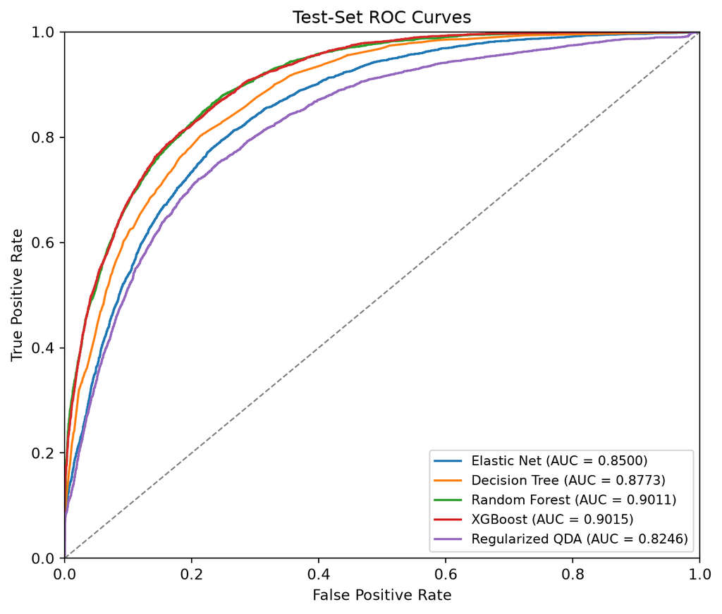

```python
plot_roc_curves(
    final_models,
    X_test_fe,
    y_test
)
plt.show()
```

The ROC curves show the trade-off between sensitivity and the false positive rate across classification thresholds. XGBoost and Random Forest have nearly overlapping curves and generally achieve higher sensitivity at a given false positive rate than the other models. All five models perform above the random-classification reference line. These ROC results support the strong discrimination of the ensemble models across thresholds.

The following three sections focus on XGBoost, which achieves the highest mean cross-validation ROC AUC and test ROC AUC among the five models. We examine its confusion matrix, native feature importance, and permutation importance to describe its classification errors and the predictors that contribute to its performance.

```python
xgboost_confusion = make_confusion_table(
    final_models["XGBoost"],
    X_test_fe,
    y_test,
    threshold=CLASSIFICATION_THRESHOLD,
)

display(xgboost_confusion)
```

|  | Predicted: Not canceled | Predicted: Canceled |
| --- | --- | --- |
| Actual: Not canceled | 11567 | 1077 |
| Actual: Canceled | 1733 | 3069 |

At the 0.50 threshold, XGBoost correctly classifies 11,567 non-canceled bookings and 3,069 canceled bookings. It incorrectly flags 1,077 non-canceled bookings as cancellations and misses 1,733 actual cancellations.

Among bookings predicted to cancel, 74.02% actually cancel, while the model identifies 63.91% of all actual cancellations. Its F1 score is 0.6860. The remaining missed cancellations show that strong overall discrimination does not guarantee that every cancellation is detected.

```python
xgboost_importance = get_model_importance(
    final_models["XGBoost"],
    top_n=20
)

display(
    xgboost_importance
    .style
    .format(precision=4)
    .hide(axis="index")
)
```

| feature | importance | magnitude |
| --- | --- | --- |
| non_refund_offline_ta_to | 0.2581 | 0.2581 |
| deposit_type_Non Refund | 0.0555 | 0.0555 |
| market_segment_Online TA | 0.0456 | 0.0456 |
| non_refund_groups | 0.0430 | 0.0430 |
| agent_9 | 0.0314 | 0.0314 |
| agent_240 | 0.0310 | 0.0310 |
| country_PRT | 0.0309 | 0.0309 |
| has_special_request | 0.0188 | 0.0188 |
| previous_cancellations_bucket_0 | 0.0177 | 0.0177 |
| distribution_channel_TA/TO | 0.0168 | 0.0168 |
| previous_cancellations_bucket_1 | 0.0168 | 0.0168 |
| agent_7 | 0.0168 | 0.0168 |
| customer_type_Transient | 0.0157 | 0.0157 |
| market_segment_Offline TA/TO | 0.0147 | 0.0147 |
| deposit_type_No Deposit | 0.0146 | 0.0146 |
| total_of_special_requests | 0.0134 | 0.0134 |
| market_segment_Direct | 0.0126 | 0.0126 |
| agent_241 | 0.0117 | 0.0117 |
| previous_cancellations | 0.0104 | 0.0104 |
| has_prior_non_canceled_booking | 0.0096 | 0.0096 |

XGBoost assigns the largest native feature importance to the interaction between non-refundable deposits and the Offline TA/TO market segment. Other highly ranked features include the Non Refund deposit indicator, the Online TA market segment, and the interaction between non-refundable deposits and group bookings. Several agent indicators and the PRT country indicator also appear among the leading features. These rankings suggest that deposit conditions and booking channels contribute to the model’s predictions. The importance and magnitude columns are identical here because the tree-based importance values are nonnegative.

```python
permutation_path = MODEL_DIR / "xgboost_permutation.joblib"
RECOMPUTE_PERMUTATION = False

if RECOMPUTE_PERMUTATION or not permutation_path.exists():
    xgboost_permutation = get_permutation_importance(
        final_models["XGBoost"],
        X_test_fe,
        y_test,
        random_state=RANDOM_STATE,
        n_repeats=5,
        n_jobs=1,
        top_n=15
    )

    dump(xgboost_permutation, permutation_path)

else:
    xgboost_permutation = load(permutation_path)

display(
    xgboost_permutation
    .style
    .format(precision=4)
    .hide(axis="index")
)
```

| feature | mean_auc_drop | std_auc_drop |
| --- | --- | --- |
| country | 0.1330 | 0.0031 |
| agent | 0.0947 | 0.0027 |
| log_lead_time | 0.0693 | 0.0017 |
| arrival_date_year | 0.0453 | 0.0015 |
| market_segment | 0.0356 | 0.0011 |
| total_of_special_requests | 0.0311 | 0.0011 |
| customer_type | 0.0286 | 0.0008 |
| adr_adj | 0.0064 | 0.0004 |
| deposit_type | 0.0063 | 0.0004 |
| total_nights_adj | 0.0055 | 0.0005 |
| previous_bookings_not_canceled | 0.0051 | 0.0004 |
| previous_cancellations | 0.0040 | 0.0004 |
| has_special_request | 0.0034 | 0.0004 |
| arrival_month_cos | 0.0034 | 0.0002 |
| arrival_month_sin | 0.0033 | 0.0002 |

Permutation importance measures the decrease in test ROC AUC when a predictor is randomly shuffled while the fitted model remains unchanged. Country produces the largest average decrease (0.1330), followed by agent (0.0947) and log-transformed lead time (0.0693). Arrival year, market segment, total special requests, and customer type also contribute substantially to predictive performance.

# Conclusion

This analysis compared five models for predicting hotel booking cancellations at the time of reservation. After removing 31,994 exact duplicates (26.8%), dropping the post-outcome variables `reservation_status` and `reservation_status_date`, and excluding 169 implausible guest records, 87,227 bookings remained with a cancellation rate of approximately 27.5%. Suspicious but potentially valid values were preserved through adjusted variables and imputed within the pipeline rather than discarded.

The two ensemble methods clearly performed best. XGBoost (0.9015) and the random forest (0.9011) led the pruned decision tree (0.8773), elastic net (0.8500), and regularized QDA (0.8246) in ROC AUC by substantial margins. The ensemble models also achieved the highest mean validation accuracy and balanced sensitivity-specificity profiles at the default classification threshold of 0.50. The XGBoost model was selected for further evaluation because it achieved the highest mean cross-validation ROC AUC and test ROC AUC among the five models.

A couple of limitations should be considered when interpreting these results. First, the random train–test split evaluates performance within the observed data distribution and may not generalize to future bookings. A chronological holdout would provide a more realistic assessment of deployment performance. Second, predicted class labels are based on a fixed probability threshold of 0.50. Because the operational costs of missed cancellations and false alarms may differ, threshold-dependent metrics may not reflect the hotel’s preferred decision trade-off. Third, removing 31,994 exact duplicates (26.8% of raw data set) assumes that identical rows are repeated records. Although this reduces the risk of duplicate observations appearing across the train–test split, the assumption cannot be verified from the available data.